# Determinants of a Healthy Diet of U.S. adults 2021-2023

```r
#### Reading the parquet file
food <- read_parquet("proc_data/food_final_morevars.parquet")
```

# 1 Introduction

The COVID-19 pandemic and subsequent geopolitical conflicts have profoundly disrupted daily life around the world, reshaping economic conditions, social behavior, and food systems. Among the most consequential—and least evenly distributed—effects of these shocks have been changes in how people access, prepare, and consume food (Pandey, Mohan, Kumar, Gangadevi, & Kurien, 2023). Lockdowns, supply chain disruptions, and sharp increases in food prices altered not only what foods were available, but also which dietary choices were feasible for different populations.

Existing research suggests that these disruptions generated mixed and often contradictory effects on dietary behavior. On the one hand, pandemic-related restrictions increased time spent at home, encouraging home cooking and, for some households, greater consumption of fruits and vegetables (Brown-University, 2025). On the other hand, rising prices of nutritious foods and shortages of key staples reduced access to healthy options, particularly relative to ultra-processed, high-sugar, and high-sodium foods (Lewis et al., 2023). Geopolitical shocks—most notably disruptions to global grain supplies following the Russian invasion of Ukraine—further intensified pressures on food affordability and availability, compounding vulnerabilities in already strained food systems.

These developments raise important questions about how dietary intake and overall diet quality vary across demographic groups and behavioral contexts during periods of heightened economic and social stress. In particular, understanding who is most at risk of excessive sugar and sodium consumption—and who is able to maintain a healthy diet despite these challenges—is central to designing effective public health interventions. Yet much of the existing literature focuses on single nutrients or broad dietary indices in isolation, limiting insight into how different dimensions of diet respond to shared structural constraints.

This paper jointly examines three interrelated aspects of diet: daily sugar intake, daily sodium intake, and the likelihood of meeting established nutritional benchmarks for a healthy diet. By analyzing these outcomes together, we provide a more comprehensive view of dietary behavior that distinguishes between nutrient-specific consumption patterns and overall diet quality.

Methodologically, we employ linear regression models to analyze sugar and sodium intake, using log-transformed measures to capture proportional differences in consumption across individuals. To assess diet quality, we estimate a logistic regression model that evaluates the probability of meeting gender-adjusted NIH dietary benchmarks, allowing for meaningful comparisons across individuals with differing nutritional requirements. Across all models, we incorporate a common set of demographic and behavioral covariates to ensure comparability and to highlight where determinants of diet overlap or diverge across outcomes.

By situating nutrient intake and diet quality within the broader context of recent global shocks, this study aims to deepen understanding of the structural and behavioral drivers of dietary risk. In doing so, it offers insights relevant for public health policy at a time when food systems face ongoing volatility and when improving diet quality remains a critical, yet unevenly achieved, public health goal.

# 2 Data

**What We Eat in America Dietary Data? National Health and Nutrition Examination Survey (NHANES) August 2021-August 2023**

The “What We Eat in America” (WWEIA) dietary data, collected between August 2021 and August 2023, form part of the National Health and Nutrition Examination Survey (NHANES) conducted by the U.S. Centers for Disease Control and Prevention (CDC) in collaboration with the U.S. Department of Agriculture (USDA). This dataset provides nationally representative information on the types and quantities of foods and beverages consumed by individuals in the United States.(U.S. Department of Agriculture, Agricultural Research Service, 2024)

Data were collected through telephone-administered 24-hour dietary recalls using the USDA’s 5-Step Automated Multiple-Pass Method (AMPM), a structured interview protocol designed to enhance accuracy and reduce underreporting. Each participant completed up to two dietary recalls, in which they reported all foods, beverages (including water), and supplements consumed from midnight to midnight on the previous day. (Williams, Terry, Akinbami, Ansai, & Ogden, 2025)

Nutrient values were derived from the USDA Food and Nutrient Database for Dietary Studies (FNDDS), which provides standardized nutrient composition data for thousands of food items. The 2021–2023 WWEIA cycle was based on an updated survey design and modified questionnaires introduced after the COVID-19 pandemic to reflect changes in food consumption patterns and supply chains.

The following dietary variables were included in the analysis: Individual ID, USDA 8-digit food code, **Energy (kcal)**, **Protein (g)**, **Carbohydrates (g)**, **Total Sugars (g)**, **Dietary Fiber (g)**, **Total Fat (g)**, and **Sodium (mg)**.

To generate individual-level daily consumption data, all foods reported under the USDA 8-digit codes were aggregated by summing nutrient quantities per individual. This approach provides the total daily nutrient intake per participant, allowing for direct comparisons across individuals and demographic groups. Aggregation by total intake—rather than mean or per-meal intake—was chosen to capture complete daily nutritional exposure, consistent with standard NHANES analytical practices. Future analyses could disaggregate these data by food category (e.g., cereals or processed foods) to examine the consumption of items most affected by recent price increases.

Demographic information was obtained from NHANES demographic files and included: **Individual ID**, **Gender**, **Age**, **Race/Hispanic origin (including Non-Hispanic Asian)**, **Education level (adults 20+)**, **Marital status**, **Household size**, and **Family income-to-poverty ratio**.

Following USDA recommendations, the analytic sample was restricted to adults aged 20 years and older to minimize bias from unequal age distributions across ethnic groups, as children’s food intake is inherently lower. Pregnant women were excluded because of their distinct nutritional requirements and dietary behaviors.

To ensure national representativeness, NHANES provides dietary day one sample weights (WTDRD1), accounting for survey design, oversampling, and non response. We identified that the distribution of demographic groups matches what Consensus Economics reports for the U.S.

While the WWEIA-NHANES data provide a robust and nationally representative source for dietary assessment, several limitations should be acknowledged. First, the 24-hour dietary recall method relies on self-reported information, which is subject to recall bias and under reporting or over reporting, particularly for foods perceived as unhealthy. Second, each participant’s recall represents only one or two days of intake, which may not fully capture habitual dietary patterns or seasonal variations. Third, the use of aggregated nutrient totals does not account for meal timing or contextual factors, such as eating location or preparation method. Finally, subgroup analyses, such as by ethnicity or income, may still be affected by smaller sample sizes and sampling variability.

Despite these limitations, WWEIA-NHANES remains one of the most comprehensive and reliable datasets for examining dietary intake and its relationship to demographic and socioeconomic characteristics in the U.S. population.

# 3 Model 1: Demographic Determinants of Sugar intake

## 3.1 Distribution of sugar

The following graph shows the distribution of daily sugar intake in grams across the sample, constructed using representative survey weights. The distribution is strongly right-skewed: most individuals consume between 50 and 150 grams of sugar per day,7 while a small fraction report extremely high intakes, with values approaching 1,000 grams within a 24-hour period.

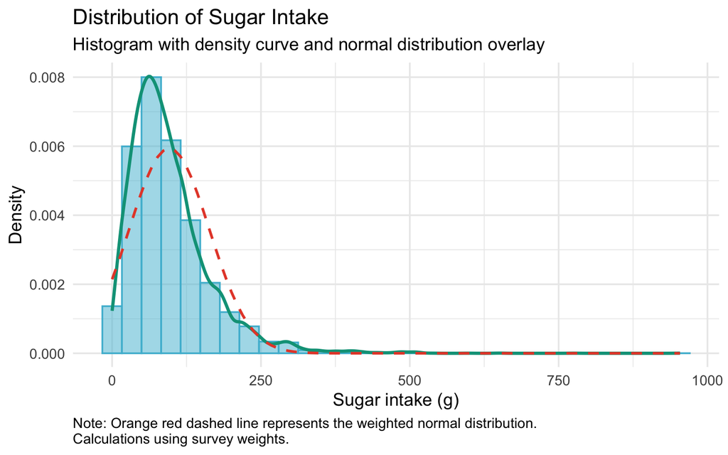

```r
survey_design <- svydesign(ids = ~1,weights = ~weight, data = food)
m_sugar  <- with(food, weighted.mean(sugar, weight, na.rm = TRUE))
sd_sugar <- with(food, {
  mu <- weighted.mean(sugar, weight, na.rm = TRUE)
  sqrt(weighted.mean((sugar - mu)^2, weight, na.rm = TRUE))
})

#Graph
ggplot(food, aes(x = sugar)) +
  geom_histogram(
    aes(
      y      = after_stat(density),
      weight = weight
    ),
    bins  = 30,
    alpha = 0.5,
    color = "#4DBBD5",
    fill  = "#4DBBD5"
  ) +
  geom_density(
    aes(weight = weight),
    color = "#00A087",
    size  = 1.2,
    alpha = 0.3,
    na.rm = TRUE
  ) +
  stat_function(
    fun  = dnorm,
    args = list(
      mean = m_sugar,
      sd   = sd_sugar
    ),
    color    = "#E64B35",
    size     = 1,
    linetype = "dashed"
  ) +
  labs(
    title    = "Distribution of Sugar Intake",
    subtitle = "Histogram with density curve and normal distribution overlay",
    x        = "Sugar intake (g)",
    y        = "Density",
    caption  = "Note: Orange red dashed line represents the weighted normal distribution.\nCalculations using survey weights."
  ) +
  theme_minimal(base_size = 14) +
  theme(
    plot.caption   = element_text(hjust = 0),
    legend.position = "bottom",
    strip.text      = element_text(face = "bold")
  )
```

To address this skewness, sugar intake is log-transformed, yielding a distribution that is more symmetric and closer to normal. However, because the logarithmic transformation compresses large values more strongly than small values, the transformation induces negative skewness in the presence of extreme upper-tail observations. As a result, the transformed variable departs from a symmetric Gaussian distribution, with a pronounced left tail.

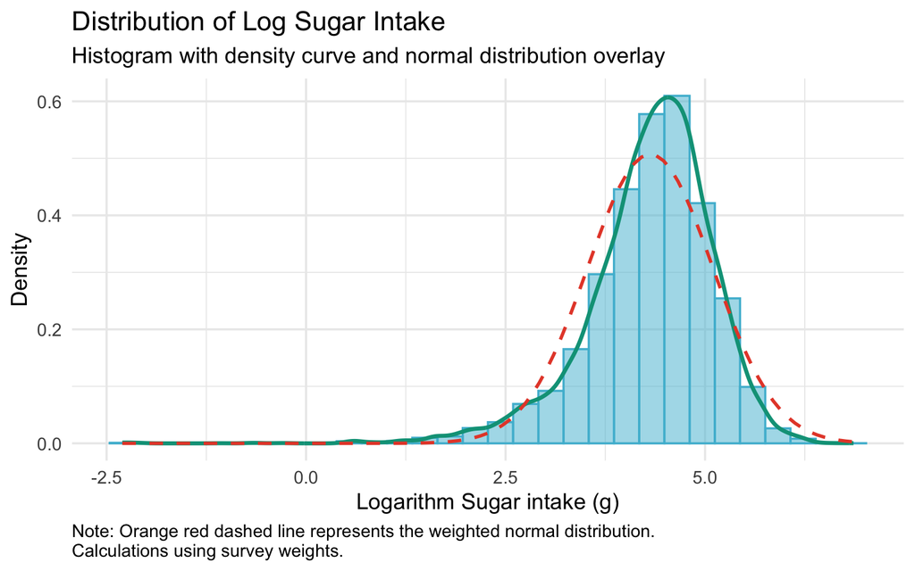

```r
#No missing in log sugar
df <- subset(food, is.finite(log_sugar) & !is.na(log_sugar))
survey_design <- svydesign(ids = ~1,weights = ~weight, data = food)

##### Distribution of Log of Sugar
## Weighted mean and sd for log_sugar
m_logsugar  <- with(df, weighted.mean(log_sugar, weight, na.rm = TRUE))
sd_logsugar <- with(df, {
  mu <- weighted.mean(log_sugar, weight, na.rm = TRUE)
  sqrt(weighted.mean((log_sugar - mu)^2, weight, na.rm = TRUE))
})

#Graph
ggplot(df, aes(x = log_sugar)) +
  geom_histogram(
    aes(
      y      = after_stat(density),
      weight = weight
    ),
    bins  = 30,
    alpha = 0.5,
    color = "#4DBBD5",
    fill  = "#4DBBD5"
  ) +
  geom_density(
    aes(weight = weight),
    color = "#00A087",
    size  = 1.2,
    alpha = 0.3,
    na.rm = TRUE
  ) +
  stat_function(
    fun  = dnorm,
    args = list(
      mean = m_logsugar,
      sd   = sd_logsugar
    ),
    color    = "#E64B35",
    size     = 1,
    linetype = "dashed"
  ) +
  labs(
    title    = "Distribution of Log Sugar Intake",
    subtitle = "Histogram with density curve and normal distribution overlay",
    x        = "Logarithm Sugar intake (g)",
    y        = "Density",
    caption  = "Note: Orange red dashed line represents the weighted normal distribution.\nCalculations using survey weights."
  ) +
  theme_minimal(base_size = 14) +
  theme(
    plot.caption   = element_text(hjust = 0),
    legend.position = "bottom",
    strip.text      = element_text(face = "bold")
  )
```

### 3.1.1 Sugar Outliers

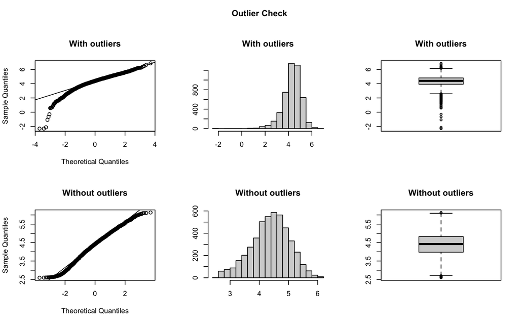

```
## Outliers identified: 160
## Proportion (%) of outliers: 3.5
## Mean of the outliers: 2.24
## Mean without removing outliers: 4.31
## Mean if we remove outliers: 4.38
## Outliers successfully removed
```

```r
### Outliers Log-Sugar
food_f = outlierKD2(df, log_sugar, rm = TRUE, boxplt = TRUE, qqplt = TRUE)
```

Achieving approximate normality would require excluding extreme observations, which would result in the removal of 3.5 percent of the sample. Importantly, excluding these observations would increase the mean level of sugar consumption, as average intake among the remaining sample is higher than in the full sample.

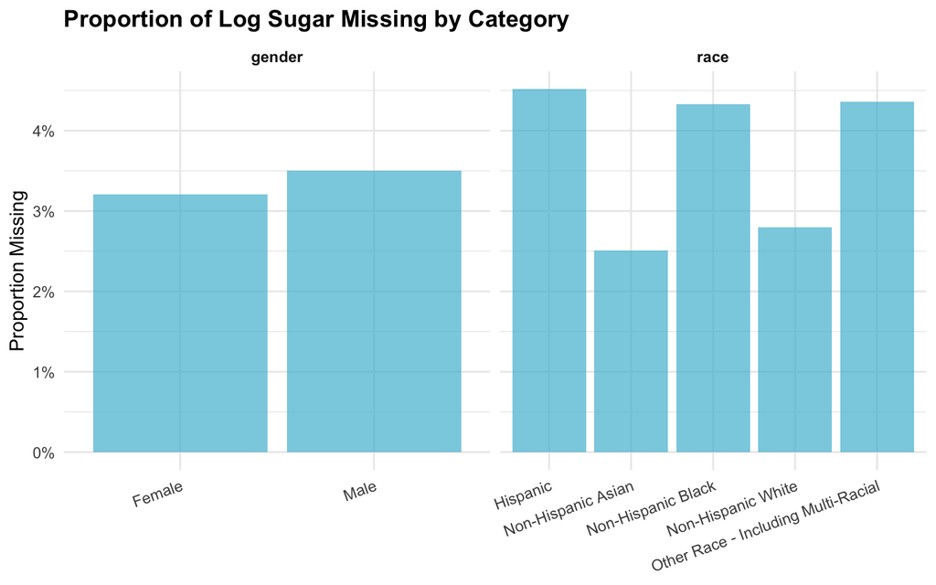

```r
cat_plot_data <- food_f %>%
  mutate(sugar_missing = is.na(log_sugar)) %>%
  pivot_longer(cols = c(gender, race),
               names_to = "variable",
               values_to = "category") %>%
  group_by(variable, category) %>%
  summarise(prop_missing = mean(sugar_missing), .groups = "drop")

cat_plot_data %>%
  mutate(category = str_to_title(category)) %>%
  ggplot(aes(x = category, y = prop_missing)) +
  geom_col(fill = "#4DBBD5", alpha=0.7) +
  facet_wrap(~ variable, scales = "free_x") +
  scale_y_continuous(labels = scales::percent) +
  labs(
    x = NULL,
    y = "Proportion Missing",
    title = "Proportion of Log Sugar Missing by Category"
  ) +
  theme_minimal(base_size = 12) +
  theme(
    axis.text.x = element_text(angle = 20, hjust = 1),
    plot.title = element_text(face = "bold"),
    strip.text = element_text(face = "bold")
  )
```

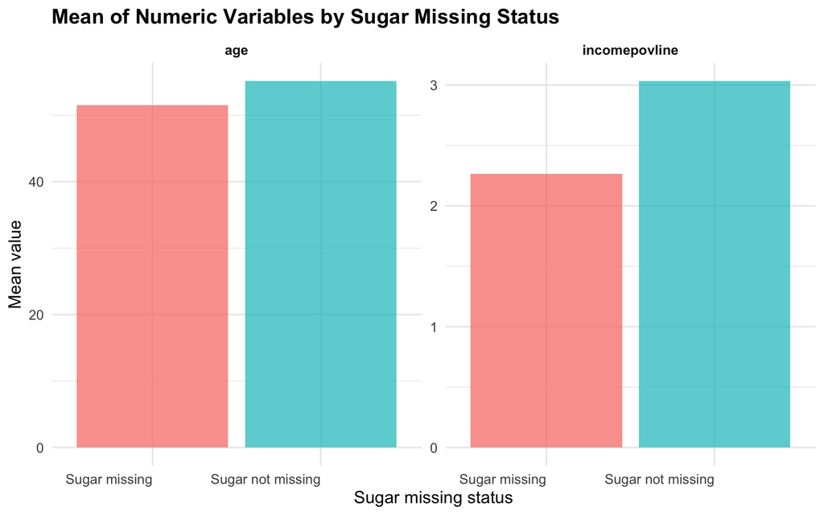

```r
num_plot_data <- food_f %>%
  mutate(sugar_missing = ifelse(is.na(log_sugar), "Sugar missing", "Sugar not missing")) %>%
  pivot_longer(cols = c(age, incomepovline),
               names_to = "variable",
               values_to = "value") %>%
  group_by(variable, sugar_missing) %>%
  summarise(mean_value = mean(value, na.rm = TRUE), .groups = "drop")

ggplot(num_plot_data,
          aes(x = sugar_missing, y = mean_value, fill = sugar_missing)) +
  geom_col(alpha=0.7) +
  facet_wrap(~ variable, scales = "free_y") +
  labs(
    x = "Sugar missing status",
    y = "Mean value",
    title = "Mean of Numeric Variables by Sugar Missing Status"
  ) +
  guides(fill = "none") +
  theme_minimal(base_size = 12) +
  theme(
    axis.text.x = element_text(hjust = 1),
    plot.title = element_text(face = "bold"),
    strip.text = element_text(face = "bold")
  )
```

Examination of the data indicates that these extreme observations are not randomly distributed. The excluded observations are disproportionately male, more likely to belong to racial and ethnic groups that are already underrepresented in the sample—particularly Hispanic, Black, and multiracial individuals—and are characterized by lower average age and income. Dropping these observations would therefore alter the demographic composition of the sample and reduce representativeness.

This presents a key modeling trade-off. Retaining the full sample implies using a dependent variable that does not fully satisfy the normality assumption underlying classical linear regression, potentially reducing efficiency and inflating standard errors. For this reason, we further examine the relationship between extreme sugar intake and demographic characteristics to assess whether these observations can be plausibly treated as random noise or whether their exclusion would introduce systematic bias.

## 3.2 Independent Variables

This section examines the bivariate relationships between daily sugar consumption and key independent variables.

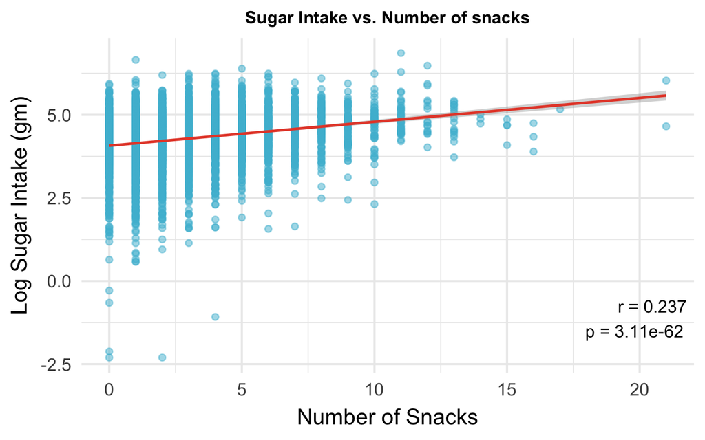

```r
##### Scatterplot of Sugar and Number of Snacks
ct <- cor.test(df$numsnacks, df$log_sugar, use = "complete.obs")
r_val <- unname(ct$estimate)   # Pearson r
p_val <- ct$p.value            # p-value
lab_text <- paste0("r = ", round(r_val, 3), "\n p = ", signif(p_val, 3))

ggplot(df, aes(x = numsnacks, y = log_sugar)) +
  geom_point(color = "#4DBBD5", alpha = 0.5, size = 2) +
  geom_smooth(method = "lm", se = TRUE, linewidth = 1, color = "#E64B35") +
  annotate(
    "text", x = Inf, y = 0, hjust  = 1.1, vjust  = 1.5, label  = lab_text, size   = 5
  ) +
  labs(
    title = "Sugar Intake vs. Number of snacks",
    x = "Number of Snacks",
    y = "Log Sugar Intake (gm)"
  ) +
  theme_minimal(base_size = 18) +
  theme(
    plot.title = element_text( hjust = 0.5, face = "bold", size = 14),
    axis.title.x = element_text(margin = margin(t = 8)),
    axis.title.y = element_text(margin = margin(r = 8))
  )
```

Sugar intake is positively associated with the number of snacks consumed during the 24-hour dietary recall period. The Pearson correlation coefficient is 0.237, with a p-value of 3.113^{-62}, allowing rejection of the null hypothesis of no linear association. This result suggests a statistically significant and non-random relationship between snack frequency and sugar intake.

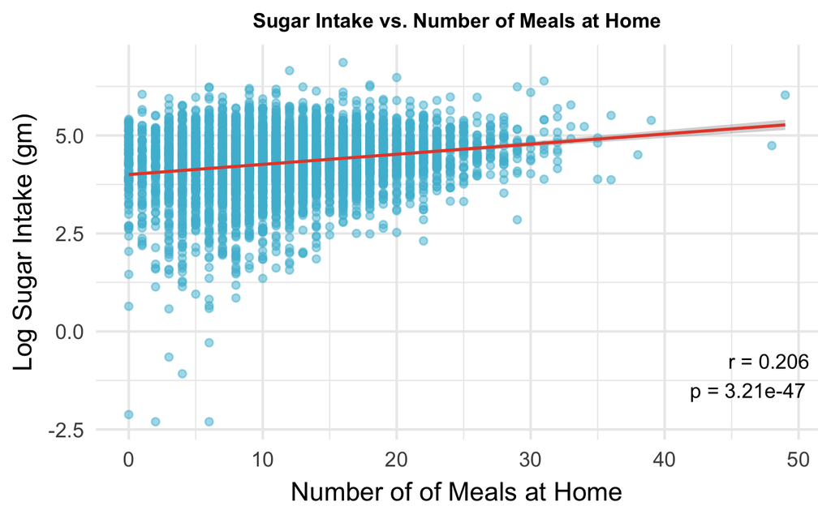

```r
##### Scatterplot of Sugar and Number of Meals at Home
ct <- cor.test(df$numhomemeals, df$log_sugar, use = "complete.obs")
r_val <- unname(ct$estimate)   # Pearson r
p_val <- ct$p.value            # p-value
lab_text <- paste0("r = ", round(r_val, 3), "\n p = ", signif(p_val, 3))

ggplot(df, aes(x = numhomemeals, y = log_sugar)) +
  geom_point(color = "#4DBBD5", alpha = 0.5, size  = 2) +
  geom_smooth(method = "lm", se = TRUE, linewidth = 1, color = "#E64B35") +
  annotate(
    "text", x = Inf, y = 0, hjust  = 1.1, vjust  = 1.5, label  = lab_text, size   = 5
  ) +
  labs(
    title = "Sugar Intake vs. Number of Meals at Home",
    x     = "Number of of Meals at Home",
    y     = "Log Sugar Intake (gm)") +
  theme_minimal(base_size = 18) +
  theme(
    plot.title   = element_text(hjust = 0.5,face  = "bold",size  = 14),
    axis.title.x = element_text(margin = margin(t = 8)),
    axis.title.y = element_text(margin = margin(r = 8))
  )
```

A positive association is also observed between sugar consumption and the number of meals consumed at home. The Pearson correlation coefficient is 0.206, with a p-value of 3.21^{-47}, indicating a statistically significant relationship. Although this finding contrasts with prior evidence linking home-prepared meals to healthier diets (Brown 2024), it may reflect a scale effect: individuals consuming more meals overall may also consume greater quantities of all nutrients, including sugar.

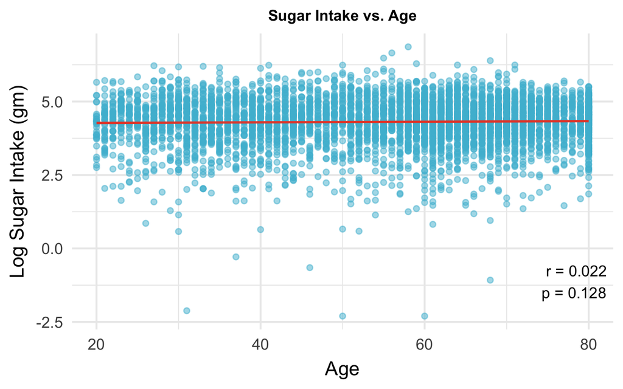

```r
##### Scatterplot of Sugar and Age
ct <- cor.test(df$age, df$log_sugar, use = "complete.obs")
r_val <- unname(ct$estimate)   # Pearson r
p_val <- ct$p.value            # p-value
lab_text <- paste0("r = ", round(r_val, 3), "\n p = ", signif(p_val, 3))

ggplot(df, aes(x = age, y = log_sugar)) +
  geom_point(color = "#4DBBD5", alpha = 0.5, size = 2) +
  geom_smooth(method = "lm", se = TRUE, linewidth = 1, color = "#E64B35") +
  annotate(
    "text", x = Inf, y = 0, hjust  = 1.1, vjust  = 1.5, label  = lab_text, size   = 5
  ) +
  labs(
    title = "Sugar Intake vs. Age",
    x = "Age",
    y = "Log Sugar Intake (gm)"
  ) +
  theme_minimal(base_size = 18) +
  theme(
    plot.title = element_text(hjust = 0.5, face = "bold", size = 14),
    axis.title.x = element_text(margin = margin(t = 8)),
    axis.title.y = element_text(margin = margin(r = 8))
  )
```

In contrast, age does not appear to be associated with sugar consumption. This is confirmed by a Pearson correlation coefficient of 0.022 and a p-value of 0.128, failing to reject the null hypothesis of no linear relationship.

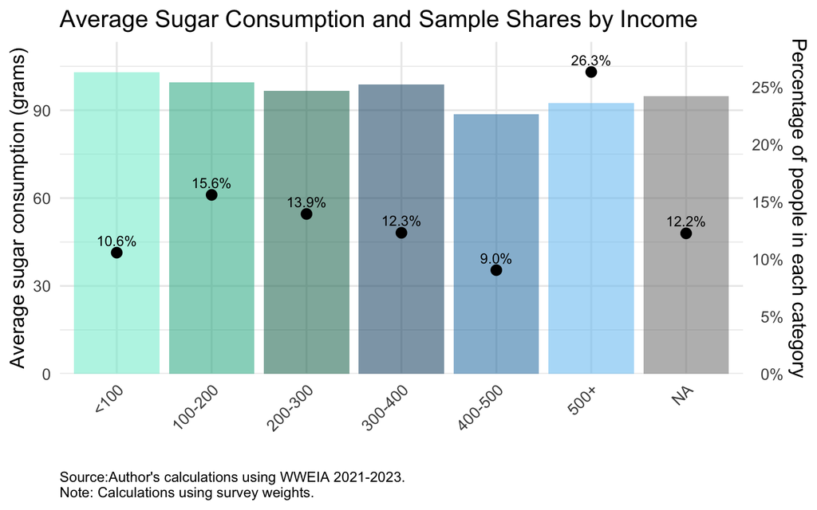

```r
my_colors <- c("<100"    = "#7AEBD1",
               "100-200"      = "#27B291",
               "200-300"      = "#12705A",
               "300-400"      = "#124E70",
               "400-500"      = "#277EB0",
               "500+" = "#6FC2F2",
               "NA" = "gray")


# ---- Prepare data: weighted sugar + within-variable shares ----
df_plot <- df %>%
  group_by(income_pov_cat) %>%
  summarise(
    weighted_n     = sum(weight, na.rm = TRUE),
    weighted_sugar = weighted.mean(sugar, weight, na.rm = TRUE),
    .groups = "drop"
  ) %>%
  mutate(
    prop  = weighted_n / sum(weighted_n),      # share within each variable
    share_label = percent(prop, accuracy = 0.1)
  ) %>%
  ungroup()
scale_factor <- max(df_plot$weighted_sugar, na.rm = TRUE) /
  max(df_plot$prop,           na.rm = TRUE)

df_plot <- df_plot %>%
  mutate(prop_scaled = prop * scale_factor)

# ---- Plot: ----
ggplot(df_plot, aes(x = income_pov_cat)) +
  geom_col(aes(y = weighted_sugar, fill = income_pov_cat, alpha = 0.4)) +
  geom_point(aes(y = prop_scaled), size = 3, color = "black") +
  geom_text(aes(y = prop_scaled, label = share_label),
            vjust = -0.7, size = 3.5) +
  scale_fill_manual(values = my_colors) +
  scale_y_continuous(
    name = "Average sugar consumption (grams)",
    expand = expansion(mult = c(0, 0.1)),
    sec.axis = sec_axis(
      ~ . / scale_factor,
      name = "Percentage of people in each category",
      breaks = seq(0, 1, by = 0.05),   # every 5%
      labels = percent_format()
    )
  ) +

  labs(
    title = "Average Sugar Consumption and Sample Shares by Income",
    caption = "Source:Author's calculations using WWEIA 2021-2023. \nNote: Calculations using survey weights.",
    x = "",
    fill = ""
  ) +
  theme_minimal(base_size = 14) +
  theme(
    legend.position = "none",
    axis.text.x = element_text(angle = 45, hjust = 1),
    plot.caption = element_text(hjust = 0, size = 10, margin = margin(t = 10))
  )
```

The previous figure presents average daily sugar consumption by income-to-poverty ratio category, reported in grams for ease of interpretation. Average sugar intake is relatively similar across income groups, at approximately 90 grams per day. The figure also displays the distribution of the sample across income categories. Approximately 10.6 percent of individuals live in households at or below 100 percent of the poverty line, while 29.6 percent fall between 100 and 300 percent—roughly corresponding to median household income in the United States. According to U.S. Census Bureau estimates, real median household income in 2024 was approximately $83,730, with an average household size of 3.15 persons, consistent with an income-to-poverty ratio near 300 percent. An additional 21.3 percent of the sample falls between 300 and 500 percent of the poverty line, and 26.3 percent resides in households at or above 500 percent.

```r
summary(aov(log_sugar ~ incomepovline, data=df))
```

```
##                 Df Sum Sq Mean Sq F value Pr(>F)
## incomepovline    1      1   0.565     0.9   0.34
## Residuals     4236   2670   0.630
## 555 observations deleted due to missingness
```

Differences in average sugar consumption across income groups are small and statistically insignificant. An ANOVA test yields a p-value of 0.34, failing to reject the null hypothesis that mean sugar intake is equal across income categories.

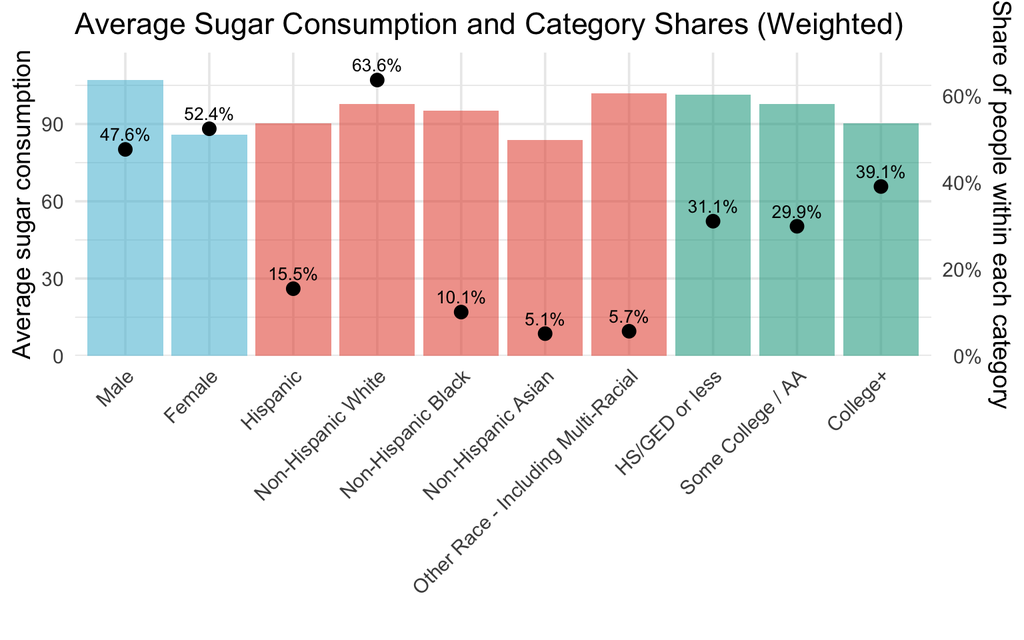

```r
my_colors <- c("gender"    = "#4DBBD5",
               "race"      = "#E64B35",
               "education" = "#00A087")


# ---- Prepare data: weighted sugar + within-variable shares ----
df_plot <- food %>%
  pivot_longer(
    cols = c(gender, race, education),
    names_to = "variable",
    values_to = "category"
  ) %>%
  group_by(variable, category) %>%
  summarise(
    weighted_n     = sum(weight, na.rm = TRUE),
    weighted_sugar = weighted.mean(sugar, weight, na.rm = TRUE),
    .groups = "drop"
  ) %>%
  group_by(variable) %>%
  mutate(
    prop  = weighted_n / sum(weighted_n),      # share within each variable
    share_label = percent(prop, accuracy = 0.1)
  ) %>%
  ungroup() %>%
  mutate(full_cat = paste(variable, category, sep = ": "))

# ---- Rescale share so dots can be plotted on sugar scale ----
scale_factor <- max(df_plot$weighted_sugar, na.rm = TRUE) /
  max(df_plot$prop,           na.rm = TRUE)

df_plot <- df_plot %>%
  mutate(prop_scaled = prop * scale_factor)

# ---- Plot----
ggplot(df_plot, aes(x = category)) +
  geom_col(aes(y = weighted_sugar, fill = variable, alpha = 0.4)) +
  geom_point(aes(y = prop_scaled), size = 3, color = "black") +
  geom_text(aes(y = prop_scaled, label = share_label),
            vjust = -0.7, size = 3.5) +
  scale_fill_manual(values = my_colors) +
  scale_y_continuous(
    name = "Average sugar consumption",
    expand = expansion(mult = c(0, 0.1)),
    sec.axis = sec_axis(
      ~ . / scale_factor,
      name   = "Share of people within each category",
      labels = percent_format()
    )
  ) +
  labs(
    title = "Average Sugar Consumption and Category Shares (Weighted)",
    x = "",
    fill = ""
  ) +
  theme_minimal(base_size = 14) +
  theme(
    legend.position = "none",
    axis.text.x = element_text(angle = 45, hjust = 1)
  )
```

This figure shows average sugar consumption by gender, race and ethnicity, and educational attainment.

```r
summary(aov(log_sugar ~ gender, data=df))
```

```
##               Df Sum Sq Mean Sq F value Pr(>F)
## gender         1     45    44.7    72.5 <2e-16 ***
## Residuals   4791   2955     0.6
## ---
## Signif. codes:  0 '***' 0.001 '**' 0.01 '*' 0.05 '.' 0.1 ' ' 1
```

Women, who comprise 52.4 percent of the sample, consume less sugar on average than men. This difference is statistically significant, with ANOVA results yielding a p-value below 2 × 10⁻¹⁶.

```r
anova_result = aov(log_sugar ~ race, data=df)
summary(anova_result)
```

```
##               Df Sum Sq Mean Sq F value Pr(>F)
## race           4     13    3.30    5.29  3e-04 ***
## Residuals   4788   2986    0.62
## ---
## Signif. codes:  0 '***' 0.001 '**' 0.01 '*' 0.05 '.' 0.1 ' ' 1
```

```r
tukeyAoV <- TukeyHSD(anova_result)
tukey_table <- tidy(tukeyAoV) %>%
  rename(
    Comparison = contrast,
    Mean_Difference = estimate,
    Lower_95CI = conf.low,
    Upper_95CI = conf.high,
    Adjusted_p = adj.p.value
  ) %>%
  mutate(Significance = ifelse(Adjusted_p < 0.05, "Significant", "Not Significant"))
kable(
  tukey_table,
  caption = "Tukey HSD Post-hoc Test for Sugar Intake Across Ethnic Groups",
  digits = 3,
  align = "lccccc"
)
```

Tukey HSD Post-hoc Test for Sugar Intake Across Ethnic Groups

| term | Comparison | null.value | Mean_Difference | Lower_95CI | Upper_95CI | Adjusted_p | Significance |
| --- | --- | --- | --- | --- | --- | --- | --- |
| race | Non-Hispanic White-Hispanic | 0 | 0.137 | 0.050 | 0.223 | 0.000 | Significant |
| race | Non-Hispanic Black-Hispanic | 0 | 0.089 | -0.031 | 0.209 | 0.255 | Not Significant |
| race | Non-Hispanic Asian-Hispanic | 0 | 0.024 | -0.147 | 0.195 | 0.996 | Not Significant |
| race | Other Race - Including Multi-Racial-Hispanic | 0 | 0.133 | -0.014 | 0.280 | 0.096 | Not Significant |
| race | Non-Hispanic Black-Non-Hispanic White | 0 | -0.048 | -0.147 | 0.052 | 0.690 | Not Significant |
| race | Non-Hispanic Asian-Non-Hispanic White | 0 | -0.113 | -0.271 | 0.045 | 0.291 | Not Significant |
| race | Other Race - Including Multi-Racial-Non-Hispanic White | 0 | -0.003 | -0.134 | 0.128 | 1.000 | Not Significant |
| race | Non-Hispanic Asian-Non-Hispanic Black | 0 | -0.065 | -0.243 | 0.113 | 0.856 | Not Significant |
| race | Other Race - Including Multi-Racial-Non-Hispanic Black | 0 | 0.044 | -0.110 | 0.199 | 0.936 | Not Significant |
| race | Other Race - Including Multi-Racial-Non-Hispanic Asian | 0 | 0.110 | -0.088 | 0.307 | 0.553 | Not Significant |

```r
summary(aov(log_sugar ~ education, data=df))
```

```
##               Df Sum Sq Mean Sq F value Pr(>F)
## education      2      1   0.553    0.88   0.41
## Residuals   4790   2998   0.626
```

Average sugar consumption declines with higher levels of educational attainment. However, despite this monotonic pattern, ANOVA results indicate that differences in mean sugar intake across education categories are not statistically significant.

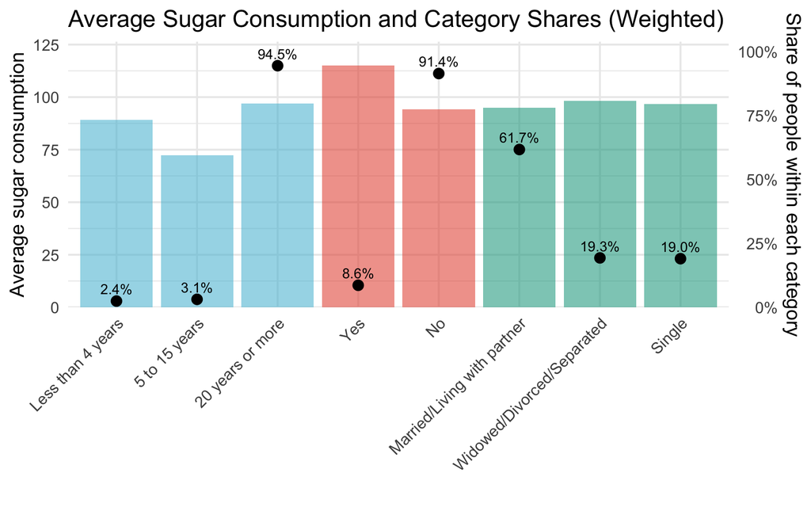

```r
my_colors <- c("timeus"    = "#4DBBD5",
               "militar"      = "#E64B35",
               "maritalstatus" = "#00A087")

df_plot <- food %>%
  pivot_longer(
    cols = c(timeus, militar, maritalstatus),
    names_to = "variable",
    values_to = "category"
  ) %>%
  group_by(variable, category) %>%
  summarise(
    weighted_n     = sum(weight, na.rm = TRUE),
    weighted_sugar = weighted.mean(sugar, weight, na.rm = TRUE),
    .groups = "drop"
  ) %>%
  group_by(variable) %>%
  mutate(
    prop  = weighted_n / sum(weighted_n),      # share within each variable
    share_label = percent(prop, accuracy = 0.1)
  ) %>%
  ungroup() %>%
  mutate(full_cat = paste(variable, category, sep = ": "))

# ---- Rescale share so dots can be plotted on sugar scale ----
scale_factor <- max(df_plot$weighted_sugar, na.rm = TRUE) /
  max(df_plot$prop,           na.rm = TRUE)

df_plot <- df_plot %>%
  mutate(prop_scaled = prop * scale_factor)

# ---- Plot----
ggplot(df_plot, aes(x = category)) +
  geom_col(aes(y = weighted_sugar, fill = variable, alpha = 0.4)) +
  geom_point(aes(y = prop_scaled), size = 3, color = "black") +
  geom_text(aes(y = prop_scaled, label = share_label),
            vjust = -0.7, size = 3.5) +
  scale_fill_manual(values = my_colors) +
  scale_y_continuous(
    name = "Average sugar consumption",
    expand = expansion(mult = c(0, 0.1)),
    sec.axis = sec_axis(
      ~ . / scale_factor,
      name   = "Share of people within each category",
      labels = percent_format()
    )
  ) +
  labs(
    title = "Average Sugar Consumption and Category Shares (Weighted)",
    x = "",
    fill = ""
  ) +
  theme_minimal(base_size = 14) +
  theme(
    legend.position = "none",
    axis.text.x = element_text(angle = 45, hjust = 1)
  )
```

```r
summary(aov(log_sugar ~ timeus, data=df))
```

```
##               Df Sum Sq Mean Sq F value Pr(>F)
## timeus         2      8    3.94    6.32 0.0018 **
## Residuals   4790   2991    0.62
## ---
## Signif. codes:  0 '***' 0.001 '**' 0.01 '*' 0.05 '.' 0.1 ' ' 1
```

```r
summary(aov(log_sugar ~ militar, data=df))
```

```
##               Df Sum Sq Mean Sq F value Pr(>F)
## militar        1     11   11.34    18.2  2e-05 ***
## Residuals   4791   2988    0.62
## ---
## Signif. codes:  0 '***' 0.001 '**' 0.01 '*' 0.05 '.' 0.1 ' ' 1
```

```r
summary(aov(log_sugar ~ maritalstatus, data=df))
```

```
##                 Df Sum Sq Mean Sq F value Pr(>F)
## maritalstatus    2      2   1.135    1.81   0.16
## Residuals     4790   2997   0.626
```

The majority of the sample has resided in the United States for 20 years or more. While some variation in sugar consumption is observed among individuals with shorter durations of residence, these groups represent a relatively small share of the sample. ANOVA results indicate statistically significant differences in sugar consumption by time spent in the United States.

Finally, individuals with military status report higher average sugar consumption than non-military respondents, and this difference is statistically significant. In contrast, average sugar consumption varies little across marital status categories, and ANOVA results fail to detect statistically significant differences.

## 3.3 Linear Model

The linear regression framework is chosen for its interpretability and its suitability for estimating conditional mean differences in sugar intake across demographic groups. Coefficients are estimated by ordinary least squares, and identification relies on within-sample variation in covariates after conditioning on the full set of controls.

### 3.3.1 Best Model ANOVA comparison

To select a parsimonious specification, we adopt a stepwise model-building approach, sequentially adding covariates and evaluating improvements in model fit. We begin with a baseline specification that includes only the number of snacks and the number of home-prepared meals, which capture key behavioral determinants of sugar intake. Additional covariates are incorporated if their inclusion improves model performance based on residual diagnostics and overall fit.

```r
#Benchmark
fit1 <- glm(log_sugar ~ numsnacks + numhomemeals, data = df)
# + gender
fit2 <- glm(log_sugar ~ numsnacks + numhomemeals + gender, data = df)
#anova(fit1,fit2)
# + education
fit3 <- glm(log_sugar ~ numsnacks + numhomemeals + gender + education, data = df)
#anova(fit1,fit2, fit3)
# + age
fit4 <- glm(log_sugar ~ numsnacks + numhomemeals + gender + education + age, data = df)
#anova(fit1,fit2, fit3, fit4)
# + age & age^2
fit5 <- glm(log_sugar ~ numsnacks + numhomemeals + gender + education + age + I(age^2), data = df)
anova(fit1,fit2, fit3, fit4, fit5)
```

```
## Analysis of Deviance Table
##
## Model 1: log_sugar ~ numsnacks + numhomemeals
## Model 2: log_sugar ~ numsnacks + numhomemeals + gender
## Model 3: log_sugar ~ numsnacks + numhomemeals + gender + education
## Model 4: log_sugar ~ numsnacks + numhomemeals + gender + education + age
## Model 5: log_sugar ~ numsnacks + numhomemeals + gender + education + age +
##     I(age^2)
##   Resid. Df Resid. Dev Df Deviance     F Pr(>F)
## 1      4790       2773
## 2      4789       2721  1     52.6 92.69 <2e-16 ***
## 3      4787       2715  2      5.0  4.43  0.012 *
## 4      4786       2713  1      2.1  3.75  0.053 .
## 5      4785       2713  1      0.3  0.62  0.432
## ---
## Signif. codes:  0 '***' 0.001 '**' 0.01 '*' 0.05 '.' 0.1 ' ' 1
```

The first set of demographic variables added includes gender and educational attainment. Both variables improve model fit and are retained. In contrast, age and a quadratic age term are not associated with improved model performance and are excluded, suggesting no meaningful linear or nonlinear relationship between age and sugar intake after accounting for other covariates.

```r
### New Benchmark
fit1 <- glm(log_sugar ~ numsnacks + numhomemeals + gender + education, data = df)
#+race
fit2 <- glm(log_sugar ~ numsnacks + numhomemeals + gender + education + race, data = df)
#anova(fit1,fit2)
#+timeus
fit3 <- glm(log_sugar ~ numsnacks + numhomemeals + gender + education + race +timeus, data = df)
#anova(fit1,fit2, fit3)
#maritalstatus
fit4 <- glm(log_sugar ~ numsnacks + numhomemeals + gender + education + race +timeus+maritalstatus, data = df)
anova(fit1,fit2, fit3, fit4)
```

```
## Analysis of Deviance Table
##
## Model 1: log_sugar ~ numsnacks + numhomemeals + gender + education
## Model 2: log_sugar ~ numsnacks + numhomemeals + gender + education + race
## Model 3: log_sugar ~ numsnacks + numhomemeals + gender + education + race +
##     timeus
## Model 4: log_sugar ~ numsnacks + numhomemeals + gender + education + race +
##     timeus + maritalstatus
##   Resid. Df Resid. Dev Df Deviance    F  Pr(>F)
## 1      4787       2715
## 2      4783       2705  4    10.50 4.64 0.00096 ***
## 3      4781       2702  2     3.44 3.04 0.04783 *
## 4      4779       2701  2     0.18 0.16 0.85559
## ---
## Signif. codes:  0 '***' 0.001 '**' 0.01 '*' 0.05 '.' 0.1 ' ' 1
```

The updated benchmark model is then augmented with race and ethnicity, time residing in the United States, and marital status. Race and ethnicity and time in the United States improve the model and are retained, while marital status does not contribute to model fit. This result is consistent with earlier descriptive analyses showing minimal variation in sugar consumption across marital status categories.

```r
### New Benchmark
fit1 <- glm(log_sugar ~ numsnacks + numhomemeals + gender + education + race +timeus, data = df)
#+militar
fit2 <- glm(log_sugar ~ numsnacks + numhomemeals + gender + education + race +timeus + militar, data = df)
anova(fit1,fit2)
```

```
## Analysis of Deviance Table
##
## Model 1: log_sugar ~ numsnacks + numhomemeals + gender + education + race +
##     timeus
## Model 2: log_sugar ~ numsnacks + numhomemeals + gender + education + race +
##     timeus + militar
##   Resid. Df Resid. Dev Df Deviance   F Pr(>F)
## 1      4781       2702
## 2      4780       2701  1    0.678 1.2   0.27
```

Next, we evaluate the inclusion of military status. Although earlier bivariate analyses indicated higher average sugar consumption among individuals with military status, the variable does not improve model fit once other demographic characteristics are included. This likely reflects both the imbalance in the distribution of military status and the fact that correlated covariates capture much of the observed variation.

```r
#+dayweek
fit2 <- glm(log_sugar ~ numsnacks + numhomemeals + gender + education + race +timeus + dayweek, data = df)
anova(fit1,fit2)
```

```
## Analysis of Deviance Table
##
## Model 1: log_sugar ~ numsnacks + numhomemeals + gender + education + race +
##     timeus
## Model 2: log_sugar ~ numsnacks + numhomemeals + gender + education + race +
##     timeus + dayweek
##   Resid. Df Resid. Dev Df Deviance    F Pr(>F)
## 1      4781       2702
## 2      4775       2700  6     1.91 0.56   0.76
```

Controlling for the day of the week on which the dietary recall was collected does not improve model performance and is therefore excluded from the final specification. This result is somewhat unexpected, given expected variance in day-specific dietary patterns, suggesting low weekday–weekend variation in sugar intake once other factors are controlled for.

```r
#+income
fit2 <- glm(log_sugar ~ numsnacks + numhomemeals + gender + education + race +timeus + income_pov_cat, data = df)
tempf1=glm(log_sugar ~ numsnacks + numhomemeals + gender + education + race +timeus, data = df[!is.na(df$income_pov_cat), ])
anova(tempf1,fit2)
```

```
## Analysis of Deviance Table
##
## Model 1: log_sugar ~ numsnacks + numhomemeals + gender + education + race +
##     timeus
## Model 2: log_sugar ~ numsnacks + numhomemeals + gender + education + race +
##     timeus + income_pov_cat
##   Resid. Df Resid. Dev Df Deviance    F Pr(>F)
## 1      4226       2410
## 2      4221       2403  5     6.72 2.36  0.038 *
## ---
## Signif. codes:  0 '***' 0.001 '**' 0.01 '*' 0.05 '.' 0.1 ' ' 1
```

```r
r.squaredGLMM(fit2)
```

```
##         R2m    R2c
## [1,] 0.0997 0.0997
```

Finally, we incorporate the income-to-poverty ratio. Although the improvement in model fit is modest, this variable is retained because it helps account for economic constraints related to food affordability and access. Including income-to-poverty ratio reduces the analytic sample size by 12.2 percent due to missing data; however, we view its inclusion as substantively important despite the associated loss of observations.

### 3.3.2 Best Model using LEAPS

```r
dffilt=df[c("log_sugar","gender", "education", "race", "timeus",
            "age", "income_pov_cat", "maritalstatus", "militar",
            "numsnacks", "numhomemeals", "dayweek")]

##### USE SUBSECT LEAPS
subfit <- regsubsets(log_sugar ~ ., data = dffilt, nvmax = 20, method = "exhaustive")

subsum <- summary(subfit)

subsum$adjr2   # adjusted R^2
```

```
##  [1] 0.0549 0.0739 0.0914 0.0934 0.0952 0.0958 0.0965 0.0974 0.0980 0.0983
## [11] 0.0985 0.0986 0.0987 0.0986 0.0986 0.0986 0.0985 0.0984 0.0984 0.0982
```

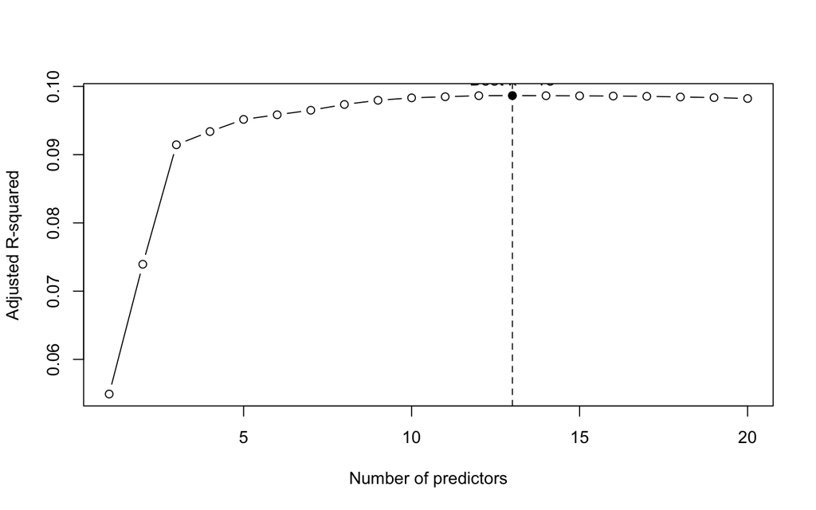

```r
#subsum$cp      # Mallows' Cp
#subsum$bic     # BIC

best_r2 <- which.max(subsum$adjr2)

best_k <- which.max(subsum$adjr2)

plot(subsum$adjr2, type = "b",
     xlab = "Number of predictors",
     ylab = "Adjusted R-squared")
abline(v = best_k, lty = 2)
points(best_k, subsum$adjr2[best_k], pch = 19)
text(best_k, subsum$adjr2[best_k],
     labels = paste0("Best k = ", best_k),
     pos = 3)
```

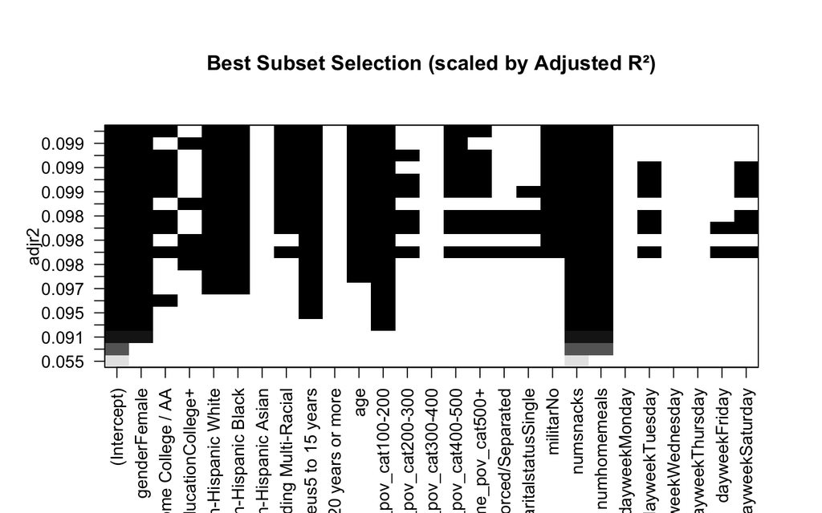

```r
best_k <- which.max(subsum$adjr2)
best_coefs <- coef(subfit, best_k)

best_tbl <- data.frame(
  term = names(best_coefs),
  estimate = unname(best_coefs),
  row.names = NULL
)

plot(subfit, scale = "adjr2")
title("Best Subset Selection (scaled by Adjusted R²)")
```

### 3.3.3 Best Model Using LASSO

We use cv.glmnet() which performs K-fold cross-validation (default: 10-fold). For each value of $\lambda$, it fits a LASSO model and computes out-of-sample mean squared error (MSE).Using lambda.1se we get the largest $\lambda$ within one standard error of the minimum MSE and therefore favors a simpler and more stable model. Under this criterion, only the number of snacks, the number of meals consumed at home, and gender are retained in the model. While this approach improves parsimony and predictive stability, it may result in underfitting and reduced interpretability, as it excludes variables, such as race and education—that previously exhibited meaningful differences in sugar consumption across categories.

```r
dffilt2 <- dffilt
names(dffilt2)[names(dffilt2) == "log_sugar"] <- "Y"
Y <- dffilt2$Y

dffilt2_complete <- na.omit(dffilt2[, c("Y","gender","education","race","maritalstatus",
                                        "timeus","income_pov_cat","militar","dayweek",
                                        "age","numsnacks","numhomemeals")])

dummies <- model.matrix(
  ~ gender + education + race + maritalstatus + timeus + income_pov_cat + militar + dayweek,
  data = dffilt2_complete
)[, -1]

dffilt_num <- data.frame(
  Y = dffilt2_complete$Y,
  dffilt2_complete[, c("timeus","age","numsnacks","numhomemeals")],
  dummies
)


x <- model.matrix(Y ~ . , data = dffilt_num)[, -1]
y <- dffilt_num$Y

cv <- cv.glmnet(x, y, alpha = 1, family = "gaussian")
coef(cv, s = "lambda.1se")
```

```
## 29 x 1 sparse Matrix of class "dgCMatrix"
##                                         lambda.1se
## (Intercept)                                 4.1032
## timeus5 to 15 years                         .
## timeus20 years or more                      .
## age                                         .
## numsnacks                                   0.0382
## numhomemeals                                0.0103
## genderFemale                               -0.0731
## educationSome.College...AA                  .
## educationCollege.                           .
## raceNon.Hispanic.White                      .
## raceNon.Hispanic.Black                      .
## raceNon.Hispanic.Asian                      .
## raceOther.Race...Including.Multi.Racial     .
## maritalstatusWidowed.Divorced.Separated     .
## maritalstatusSingle                         .
## timeus5.to.15.years                         .
## timeus20.years.or.more                      .
## income_pov_cat100.200                       .
## income_pov_cat200.300                       .
## income_pov_cat300.400                       .
## income_pov_cat400.500                       .
## income_pov_cat500.                          .
## militarNo                                   .
## dayweekMonday                               .
## dayweekTuesday                              .
## dayweekWednesday                            .
## dayweekThursday                             .
## dayweekFriday                               .
## dayweekSaturday                             .
```

## 3.4 Selected Model

Using an ANOVA-based stepwise model selection approach, the final selected model is a linear regression of the logarithm of daily sugar intake on the number of snacks consumed, the number of home-prepared meals, gender, educational attainment, race and ethnicity, time residing in the United States, and the income-to-poverty ratio. This specification controls for key dietary behaviors and demographic characteristics that jointly explain variation in sugar consumption, while excluding variables that do not contribute to model fit.

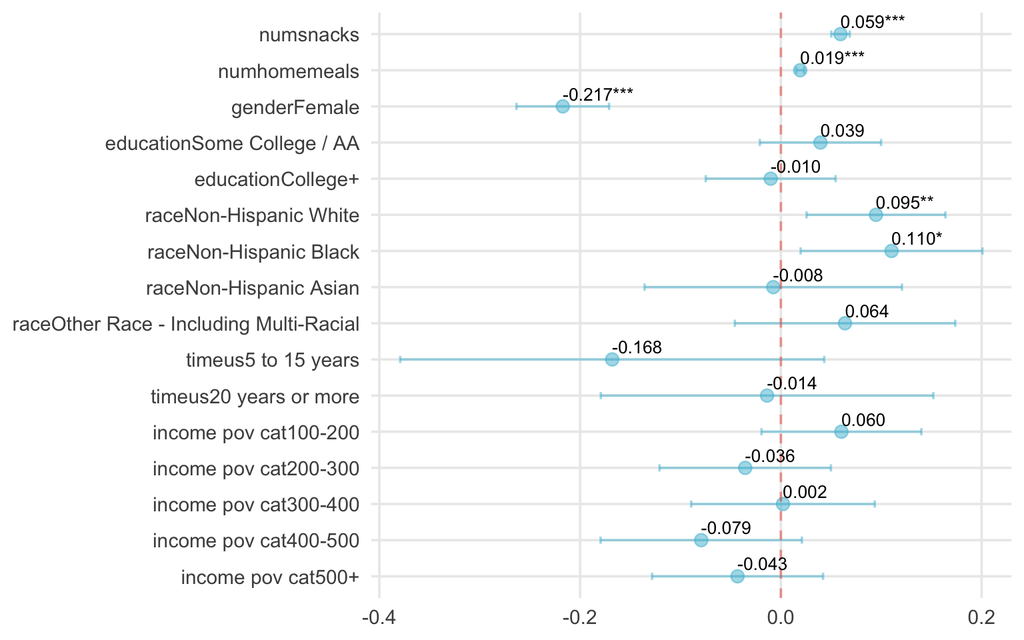

```r
dffinal=df[!is.na(df$income_pov_cat), ]
fitfinal=glm(log_sugar ~ numsnacks + numhomemeals + gender + education + race +timeus + income_pov_cat, data = dffinal)

## Coefplot
coef_df <- tidy(fitfinal, conf.int = TRUE) %>%
  filter(term != "(Intercept)") %>%
  mutate(
    # significance stars
    sig = case_when(
      p.value < 0.001 ~ "***",
      p.value < 0.01  ~ "**",
      p.value < 0.05  ~ "*",
      TRUE ~ ""
    ),
    coef_label = sprintf("%.3f%s", estimate, sig),
    term = gsub("_", " ", term),
    term = factor(term, levels = rev(unique(term)))
  )

ggplot(coef_df, aes(x = term, y = estimate)) +
  geom_point(size = 3, color = "#4DBBD5", alpha=0.5) +
  geom_errorbar(aes(ymin = conf.low, ymax = conf.high),
                width = 0.2, color = "#4DBBD5", alpha=0.5) +
  geom_hline(yintercept = 0, linetype = "dashed", alpha = 0.5, color="#E64B35") +
  geom_text(aes(label = coef_label), vjust=-0.5,
            hjust = 0, size = 3.5) +
  coord_flip() +
  labs(
    x = NULL,
    y = NULL
  ) +
  theme_minimal(base_size = 14) +
  theme(
    plot.title = element_text(face = "bold", hjust = 0.5),
    axis.title.y = element_blank(),
    panel.grid.minor = element_blank()
  )
```

The results show that a higher number of snacks was significantly associated with greater sugar intake. Specifically, each additional snack was associated with an approximately 6.1% increase in sugar intake ($\beta_{s}$ = 0.059, p < 0.001), holding all other variables constant. Similarly, each additional home-prepared meal was associated with a 1.9% increase in sugar intake ($\beta_{m}$ = 0.019, p < 0.001).

There are large gender differences in sugar intake, with females consuming significantly less sugar than males. Compared with males, females had an estimated 19.5% lower sugar intake ($\beta_{g}$ = −0.217, p < 0.001).

Educational attainment was not significantly associated with sugar intake. Compared with individuals with a high school education or less, those with some college or an associate degree had an estimated 4.0% higher sugar intake ($\beta_{e}$ = 0.039, p = 0.201), while those with a college degree or higher had a 1.0% lower sugar intake ($\beta_{g}$ = −0.010, p = 0.759).

With respect to race and ethnicity, Non-Hispanic White and Non-Hispanic Black individuals had significantly higher sugar intake compared with Hispanic individuals. Non-Hispanic White participants consumed approximately 9.9% more sugar ($\beta_{r}$ = 0.095, p = 0.007), while Non-Hispanic Black participants consumed approximately 11.7% more sugar ($\beta_{r}$ = 0.110, p = 0.017). No statistically significant differences were observed for Non-Hispanic Asian individuals or those identifying as other or multi-racial.

Time residing in the United States was not significantly associated with sugar intake. Compared with individuals who had lived in the United States for less than five years, those residing for 5–15 years had an estimated 15.5% lower sugar intake ($\beta_{tu}$ = −0.168, p = 0.119), and those residing for 20 years or more had a 1.4% lower sugar intake ($\beta_{tu}$ = −0.014, p = 0.871).

```r
r.squaredGLMM(fitfinal)
```

```
##         R2m    R2c
## [1,] 0.0997 0.0997
```

```r
#Null
pchisq(2670.1, 4237, lower.tail=F)
```

```
## [1] 1
```

```r
#Fitt
pchisq(2398.4, 4219, lower.tail=F)
```

```
## [1] 1
```

```r
#Best?
pchisq(2670.1-2398.4, 4237-4219, lower.tail=F)
```

```
## [1] 3.06e-47
```

The model has a low $R^2$ of only 0.0997 which implies that demographic characteristics fall short on explaining sugar consumption, then unobserved patterns such a behavioral variables or geography accessibility to healthy food could be omitted variables that might explain sugar consumption. Compared to the Null model, the Fitted Model was a smaller Residual deviance compared to the saturated model.

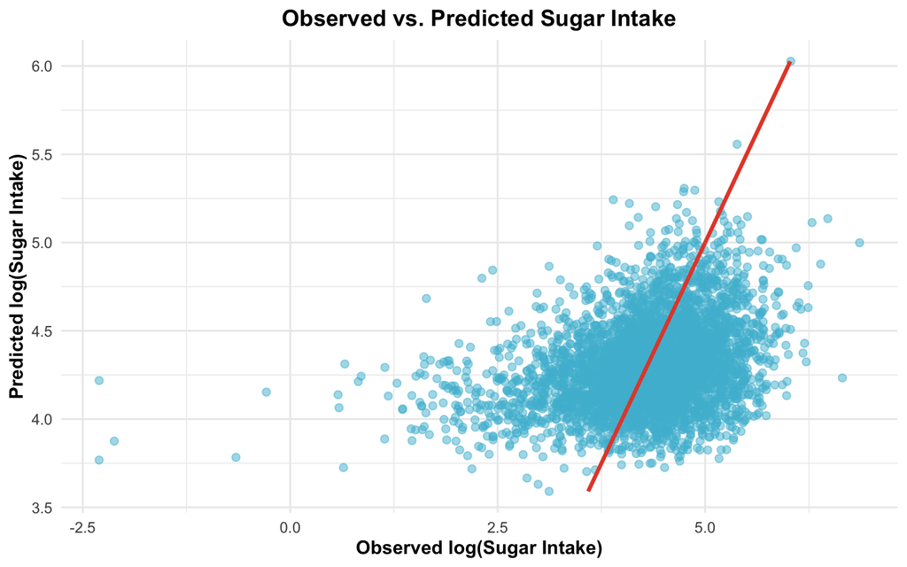

```r
# Saving the predictions:
dfwithpred <- add_predictions(dffinal,fitfinal)
#Plot predictions vs real value
ggplot(dfwithpred, aes(x = log_sugar, y = pred)) +
  geom_point(alpha = 0.5, color = "#4DBBD5", size = 2) +
  geom_line(aes(pred), colour = "#E64B35", size = 1.2) +
  labs(
    x = "Observed log(Sugar Intake)",
    y = "Predicted log(Sugar Intake)",
    title = "Observed vs. Predicted Sugar Intake"
  ) +
  theme_minimal(base_size = 12) +
  theme(
    plot.title = element_text(face = "bold", hjust = 0.5),
    axis.title = element_text(face = "bold")
  )
```

The previous plot shows how the linear model might not be the best approach for this analysis as we are very weakly predicting the sugar intake with demographic variables.

```r
check_collinearity(fitfinal)
```

```
## # Check for Multicollinearity
##
## Low Correlation
##
##            Term  VIF   VIF 95% CI adj. VIF Tolerance Tolerance 95% CI
##       numsnacks 1.12 [1.09, 1.17]     1.06      0.89     [0.86, 0.92]
##    numhomemeals 1.15 [1.12, 1.20]     1.07      0.87     [0.84, 0.90]
##          gender 1.02 [1.00, 1.10]     1.01      0.98     [0.91, 1.00]
##       education 1.46 [1.41, 1.52]     1.10      0.68     [0.66, 0.71]
##            race 1.32 [1.28, 1.38]     1.04      0.76     [0.73, 0.78]
##          timeus 1.15 [1.12, 1.20]     1.04      0.87     [0.84, 0.90]
##  income_pov_cat 1.50 [1.44, 1.56]     1.04      0.67     [0.64, 0.69]
```

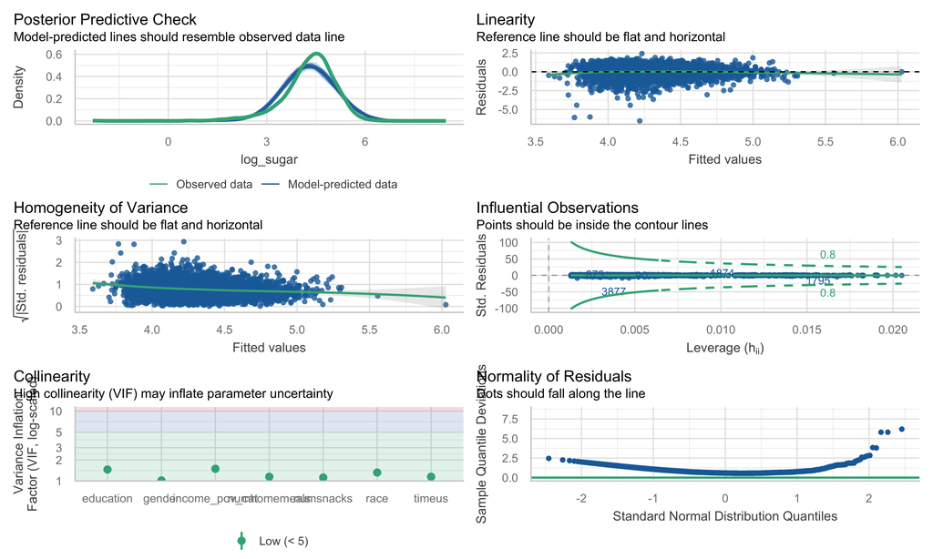

```r
check_heteroscedasticity(fitfinal)
check_model(fitfinal)
```

The Q–Q plot of the residuals reveals a substantial deviation from the 45-degree reference line in the upper tail. Specifically, the sample quantiles exceed the corresponding theoretical quantiles, indicating that the normality assumption of the residuals is violated in this model.

The Scale–Location plot further confirms the presence of heteroskedasticity, as the variance of the residuals is not constant across the range of fitted values.

The Residuals versus Leverage plot is used to identify influential observations. Although several observations exhibit relatively high residuals, none exceed the Cook’s distance threshold. This suggests that, while extreme values in sugar consumption may reduce the efficiency of the model, they are not influential enough to substantially affect the estimated coefficients or overall conclusions.

Finally, an assessment of multicollinearity indicates no cause for concern. Variance Inflation Factor (VIF) values for all independent variables are close to 1, suggesting a low degree of correlation among predictors and confirming that multicollinearity is not a significant issue in this model.

## 3.5 Conclusion Sugar Model

This study examines the demographic and behavioral correlates of daily sugar consumption using a linear regression framework with log-transformed intake. The results highlight the central role of eating behaviors in explaining variation in sugar intake. In particular, the number of snacks consumed is strongly and positively associated with sugar intake, with each additional snack corresponding to a meaningful increase in consumption. Home-prepared meals are also positively associated with sugar intake, suggesting that higher overall meal frequency may be linked to greater total sugar exposure rather than reflecting diet quality alone.

Substantial heterogeneity is observed across demographic groups. Females consume significantly less sugar than males, even after controlling for dietary behaviors and socioeconomic characteristics. Racial and ethnic differences are also evident, with Non-Hispanic White and Non-Hispanic Black individuals exhibiting higher sugar intake than Hispanic individuals. In contrast, educational attainment, time residing in the United States, and income-to-poverty ratio are not significantly associated with sugar intake in the multivariable framework. The absence of a clear income gradient suggests that economic resources alone may be insufficient to explain patterns of sugar consumption.

Despite identifying several statistically significant associations, the model explains a relatively small share of the overall variation in sugar intake. This finding indicates that demographic characteristics capture only a limited portion of the determinants of sugar consumption and points to the importance of unobserved factors such as individual preferences, dietary habits, food environments, and geographic access to healthy options. Diagnostic analyses further reveal heteroskedasticity and deviations from normality in the residuals, implying reduced efficiency of the estimates, although no influential observations are detected and multicollinearity does not appear to be a concern.

These findings have important policy implications. The lack of significant differences in sugar intake across income groups suggests that policies narrowly targeted by income may have limited effectiveness in reducing overall sugar consumption. While fiscal interventions such as sugar-sweetened beverage taxes remain a prominent policy tool((Backholer et al., 2016); (Sharma, Hauck, Hollingsworth, & Siciliani, 2014)), the results underscore the potential value of broader strategies. Interventions aimed at improving access to healthy foods((Walker, Keane, & Burke, 2010)), reducing geographic disparities in food environments((CDC, 2024)), enhancing nutrition education((Toomer, 2016); (Silva, Araújo, Lopes, & Ray, 2023)), and strengthening food labeling((Dumoitier, Abbo, Neuhofer, & McFadden, 2019)) may be more effective in addressing excessive sugar consumption at the population level. Future research incorporating behavioral measures and spatial indicators of food access could further improve understanding of the mechanisms underlying sugar intake and inform more targeted policy responses.

# 4 Model 2: Demographic Determinants of Sodium intake

```r
food <- read_parquet("proc_data/food_final_morevars.parquet")
# Subset with only focus variables
food_model <- subset(food, select = c(gender,age,race,timeus,hhsize,income_pov_cat,sodium))
# Drop missing values
food_model <-  food_model[!is.na(food_model$income_pov_cat),]
```

## 4.1 Distribution of Sodium intake

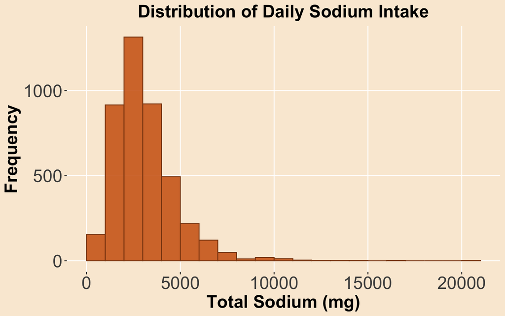

```r
hsodium <- ggplot(food_model, aes(sodium)) +
  geom_histogram(
    breaks=seq(0, 21000, by = 1000),
    fill = "chocolate",
    color = "chocolate4",
    alpha = 0.9
  ) +
  labs(
    title = "Distribution of Daily Sodium Intake",
    x = "Total Sodium (mg)",
    y = "Frequency"
  ) +
  theme(
    # Background colors
    plot.background = element_rect(fill = "antiquewhite", color = NA),   # outside area
    panel.background = element_rect(fill = "antiquewhite", color = NA),  # plot area
    panel.grid.major = element_line(color = "white"),             # optional: lighten grid
    panel.grid.minor = element_blank(),

    # Font sizes
    plot.title = element_text(size = 20, face = "bold", hjust = 0.5),  # title
    axis.title = element_text(size = 20, face = "bold"),               # axis titles
    axis.text = element_text(size = 20)                                # axis labels
  )

# Display the plot
hsodium
```

**Sodium intake is heavily right-skewed which shows that most people consume moderate amounts, but there are few extreme outliers with very high intakes.**

## 4.2 Independent Variables

### 4.2.1 Boxplot of Sodium Intake by genders

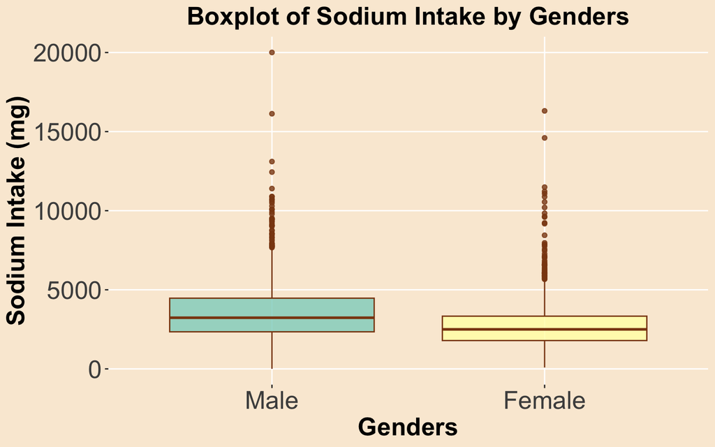

```r
box_sodium_gender <- ggplot(food_model, aes(x = gender, y = sodium, fill = gender)) +
  geom_boxplot(
    alpha = 0.8,
    color = "chocolate4"
  ) +
  scale_fill_brewer(
    palette = "Set3"
  ) +
  labs(
    title = "Boxplot of Sodium Intake by Genders",
    x = "Genders",
    y = "Sodium Intake (mg)"
  ) +
  theme(
    # Background colors
    plot.background = element_rect(fill = "antiquewhite", color = NA),
    panel.background = element_rect(fill = "antiquewhite", color = NA),
    panel.grid.major = element_line(color = "white"),
    panel.grid.minor = element_blank(),

    #Font sizes
    plot.title = element_text(size = 20, face = "bold", hjust = 0.5),
    axis.title = element_text(size = 20, face = "bold"),
    axis.text  = element_text(size = 20),
    legend.position = "none"
  )
# Display the plot
box_sodium_gender
```

**This boxplot compares sodium intake by gender. We can see that Males have a higher median sodium intake and a wider range of consumption compared to Females.**

### 4.2.2 Scatterplot of Sodium Intake by different ages

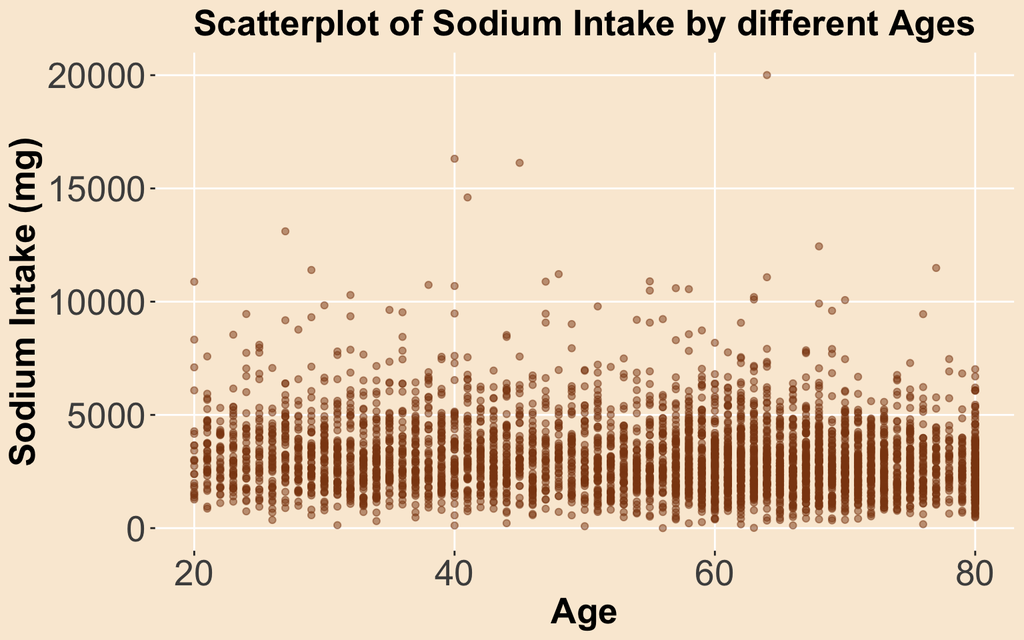

```r
scatter_sodium_age <- ggplot(food_model, aes(x = age, y = sodium)) +
  geom_point(
    alpha = 0.5,
    color = "chocolate4"
    ) +
  scale_fill_brewer(
    palette = "Set3"
    ) +
  labs(
    title = "Scatterplot of Sodium Intake by different Ages",
    x = "Age",
    y = "Sodium Intake (mg)"
    ) +
  theme(
    # Background colors
    plot.background = element_rect(fill = "antiquewhite", color = NA),
    panel.background = element_rect(fill = "antiquewhite", color = NA),
    panel.grid.major = element_line(color = "white"),
    panel.grid.minor = element_blank(),

    #Font sizes
    plot.title = element_text(size = 20, face = "bold", hjust = 0.5),
    axis.title = element_text(size = 20, face = "bold"),
    axis.text  = element_text(size = 20),
    legend.position = "none"
    )
# Display the plot
scatter_sodium_age
```

**This scatterplot of sodium intake versus Age shows that data is quite dense, revealing a lot of variability at every age, but it shows that consumption of sodium decreases as people get older.**

### 4.2.3 Boxplot of Sodium Intake by different Ethnic Groups

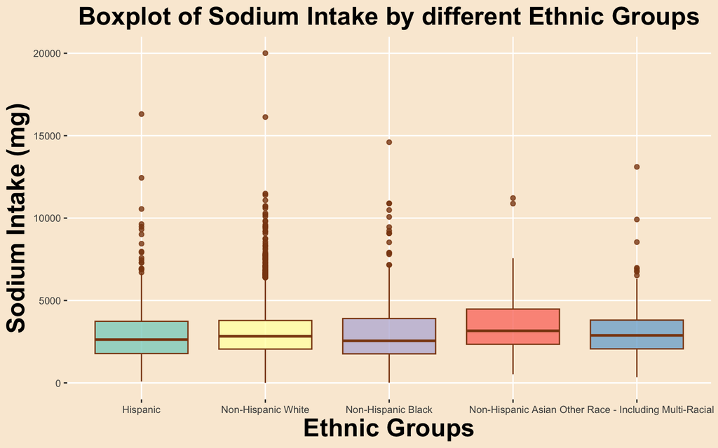

```r
box_sodium_ethnic <- ggplot(food_model, aes(x = race, y = sodium, fill = race)) +
  geom_boxplot(
    alpha = 0.8,
    color = "chocolate4"
  ) +
  scale_fill_brewer(
    palette = "Set3"
  ) +
  labs(
    title = "Boxplot of Sodium Intake by different Ethnic Groups",
    x = "Ethnic Groups",
    y = "Sodium Intake (mg)"
  ) +
  theme(
    # Background colors
    plot.background = element_rect(fill = "antiquewhite", color = NA),
    panel.background = element_rect(fill = "antiquewhite", color = NA),
    panel.grid.major = element_line(color = "white"),
    panel.grid.minor = element_blank(),

    #Font sizes
    plot.title = element_text(size = 20, face = "bold", hjust = 0.5),
    axis.title = element_text(size = 20, face = "bold"),
    axis.text  = element_text(size = 8),
    legend.position = "none"
  )
# Display the plot
box_sodium_ethnic
```

### 4.2.4 Boxplot of Sodium Intake by different Income Groups

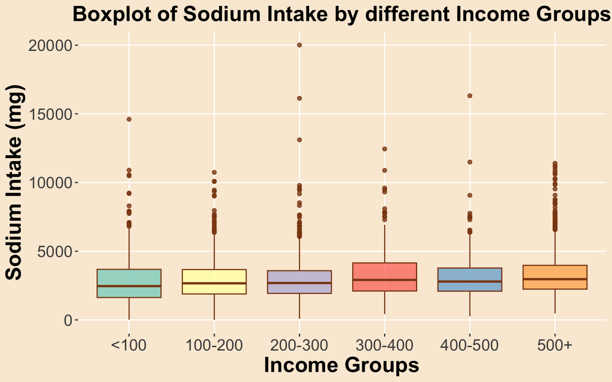

```r
box_sodium_income <- ggplot(food_model, aes(x = income_pov_cat, y = sodium, fill = income_pov_cat)) +
  geom_boxplot(
    alpha = 0.8,
    color = "chocolate4"
  ) +
  scale_fill_brewer(
    palette = "Set3"
  ) +
  labs(
    title = "Boxplot of Sodium Intake by different Income Groups",
    x = "Income Groups",
    y = "Sodium Intake (mg)"
  ) +
  theme(
    # Background colors
    plot.background = element_rect(fill = "antiquewhite", color = NA),
    panel.background = element_rect(fill = "antiquewhite", color = NA),
    panel.grid.major = element_line(color = "white"),
    panel.grid.minor = element_blank(),

    #Font sizes
    plot.title = element_text(size = 20, face = "bold", hjust = 0.5),
    axis.title = element_text(size = 20, face = "bold"),
    axis.text  = element_text(size = 15),
    legend.position = "none"
  )
# Display the plot
box_sodium_income
```

**This shows the relationship between income and sodium.In this income is categorized by the ‘income-to-poverty ratio’.From the lowest income group (<100) on the left to the highest income group (500+) on the right, we observe a slight upward trend in median sodium intake. This suggests that higher socioeconomic status is actually associated with higher sodium consumption.**

### 4.2.5 Allpairs plot

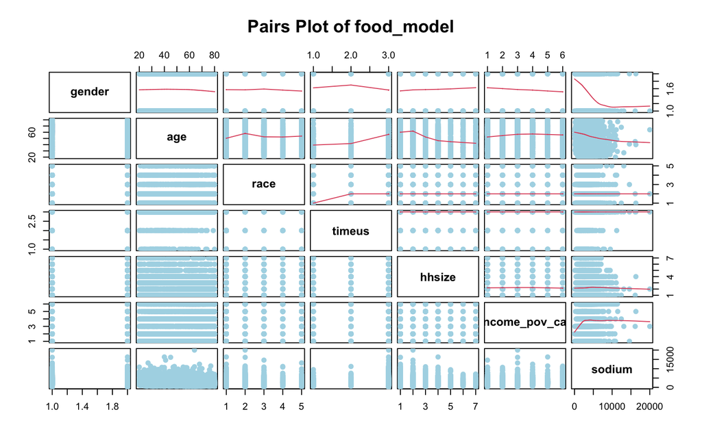

```r
pairs_plot <- pairs(food_model,
      labels = colnames(food_model),
      lower.panel = points,
      upper.panel = panel.smooth,
      diag.panel = NULL,
      gap = 0.5,
      cex.labels = 1.2,
      font.labels = 2,
      pch = 19,
      col = "lightblue",
      main = "Pairs Plot of food_model")
```

**This pairwise plot checks for correlations between all the variables.The relationship with age shows a downward trend, confirming the earlier observation. The relationship with household size appears relatively flat, suggesting weak association. We don’t see any perfect straight lines, which tells us that no single variable perfectly predicts sodium intake on its own. It also helps us confirm that our predictors aren’t too heavily correlated with each other, which avoids multicollinearity issues.**

### 4.2.6 Correlation Matrix and plot

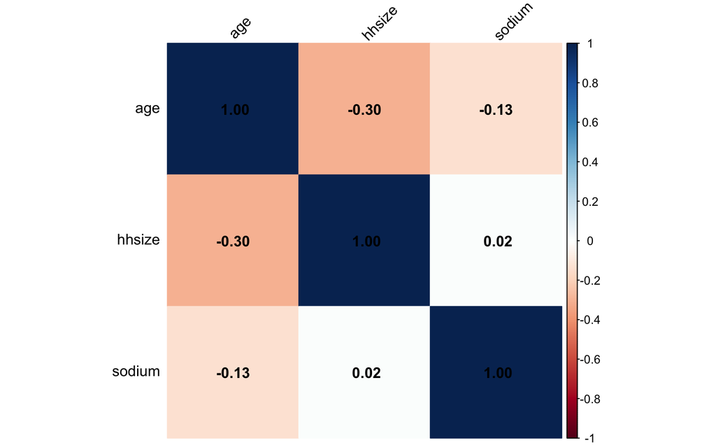

```r
#Subset of only numerical variables
food_model_num <- food_model[,c("age","hhsize","sodium")]
cor_matrix <- cor(food_model_num)
corrplot::corrplot(cor_matrix,
                   method = "color",
                   type = "full",
                   addCoef.col = "black",
                   tl.col = "black",
                   tl.srt = 45,
                   diag = TRUE)
```

**Correlation matrix and plot with the subset to only numerical variables age, hhsize and sodium.We can see that age and sodium are negtively correlated while hhsize and sodium are positively correlated.**

## 4.3 Linear Models

### 4.3.1 Model-1 with only numerical variables (age and hhsize)

```r
model1 = lm(sodium ~ age+hhsize, data = food_model)
summary(model1)
```

```
##
## Call:
## lm(formula = sodium ~ age + hhsize, data = food_model)
##
## Residuals:
##    Min     1Q Median     3Q    Max
##  -3149  -1068   -286    730  17036
##
## Coefficients:
##             Estimate Std. Error t value Pr(>|t|)
## (Intercept)  3896.51     111.45   34.96   <2e-16 ***
## age           -13.60       1.55   -8.76   <2e-16 ***
## hhsize        -27.96      18.85   -1.48     0.14
## ---
## Signif. codes:  0 '***' 0.001 '**' 0.01 '*' 0.05 '.' 0.1 ' ' 1
##
## Residual standard error: 1610 on 4237 degrees of freedom
## Multiple R-squared:  0.0181, Adjusted R-squared:  0.0177
## F-statistic: 39.1 on 2 and 4237 DF,  p-value: <2e-16
```

```r
xkabledply(model1, title = "Model for sodium with age and hhsize as regressors" )
```

Model for sodium with age and hhsize as regressors

|  | Estimate | Std. Error | t value | Pr(>&#124;t&#124;) |
| --- | --- | --- | --- | --- |
| (Intercept) | 3896.5 | 111.45 | 34.96 | 0.000 |
| age | -13.6 | 1.55 | -8.76 | 0.000 |
| hhsize | -28.0 | 18.85 | -1.48 | 0.138 |

```r
xkablevif(model1)
```

VIFs of Model: sodium ~ age + hhsize

| age | hhsize |
| --- | --- |
| 1.1 | 1.1 |

**We chose age and hhsize as the initial predictors because they are key numerical demographic variables**

**Coefficient Interpretation**

- **Intercept = 3896.513**, which represents the expected daily sodium intake (in milligrams) when both age and household size are zero. While this scenario is not practically meaningful, the intercept serves as a baseline level of sodium intake against which the effects of age and household size are measured.
- **Age Coefficient = −13.605**, For every one-year increase in age, daily sodium intake decreases by approximately 13.6 mg on average, holding household size constant.This shows a negative linear relationship between age and sodium intake, suggesting that older individuals tend to consume less sodium than younger individuals.
- **hhsize Coefficient = −27.961**, For each additional household member, sodium intake decreases by approximately 28 mg on average, holding age constant.

**P-Values:**

- **Intercept p-value < 2e-16**. This is highly statistically significant, indicating strong evidence that the baseline sodium intake differs from zero.
- **Age p-value < 2e-16**.This extremely small p-value indicates that age is a highly significant predictor of sodium intake. We reject the null hypothesis that the age coefficient equals zero.
- **hhsize p-value = 0.138**. This p-value exceeds alpha levels (0.05), so we fail to reject the null hypothesis for household size. Thus, household size does not significantly predict sodium intake in this model.

**Mutiple R-squared = 0.018113 (1.81%)**. This model explains approximately 1.8% of the total variation in daily sodium intake. This indicates that age and household size alone capture only a small portion of the factors influencing sodium consumption.

**Adjusted R-squared = 0.01767**. The adjusted value confirms the limited explanatory power of the model after accounting for the number of predictors.

**F-statistic p-value < 2.2e-16**.The overall model is statistically significant, meaning that at least one predictor (in this case, age) is associated with sodium intake.

**This baseline model shows that age is a strong and statistically significant predictor of sodium intake, with older individuals consuming less sodium on average. However, household size does not have a significant effect, and the low R-squared value indicates that most of the variation in sodium intake is explained by other demographic and socioeconomic factors not included in this model.**

### 4.3.2 Model-2 with all focus variables (including categorical)

```r
model2 = lm(sodium ~ age+gender+race+income_pov_cat+timeus, data = food_model)
summary(model2)
```

```
##
## Call:
## lm(formula = sodium ~ age + gender + race + income_pov_cat +
##     timeus, data = food_model)
##
## Residuals:
##    Min     1Q Median     3Q    Max
##  -3470  -1004   -254    709  16588
##
## Coefficients:
##                                         Estimate Std. Error t value Pr(>|t|)
## (Intercept)                              3848.21     186.75   20.61  < 2e-16
## age                                       -14.71       1.46  -10.08  < 2e-16
## genderFemale                             -862.96      47.95  -18.00  < 2e-16
## raceNon-Hispanic White                    158.34      71.92    2.20   0.0278
## raceNon-Hispanic Black                    126.50      94.39    1.34   0.1803
## raceNon-Hispanic Asian                    392.32     132.83    2.95   0.0032
## raceOther Race - Including Multi-Racial   178.81     114.10    1.57   0.1171
## income_pov_cat100-200                     100.61      82.96    1.21   0.2253
## income_pov_cat200-300                     165.27      87.42    1.89   0.0588
## income_pov_cat300-400                     388.06      93.13    4.17  3.1e-05
## income_pov_cat400-500                     182.99     101.13    1.81   0.0704
## income_pov_cat500+                        326.12      81.10    4.02  5.9e-05
## timeus5 to 15 years                        -8.10     220.55   -0.04   0.9707
## timeus20 years or more                    188.20     173.53    1.08   0.2782
##
## (Intercept)                             ***
## age                                     ***
## genderFemale                            ***
## raceNon-Hispanic White                  *
## raceNon-Hispanic Black
## raceNon-Hispanic Asian                  **
## raceOther Race - Including Multi-Racial
## income_pov_cat100-200
## income_pov_cat200-300                   .
## income_pov_cat300-400                   ***
## income_pov_cat400-500                   .
## income_pov_cat500+                      ***
## timeus5 to 15 years
## timeus20 years or more
## ---
## Signif. codes:  0 '***' 0.001 '**' 0.01 '*' 0.05 '.' 0.1 ' ' 1
##
## Residual standard error: 1540 on 4226 degrees of freedom
## Multiple R-squared:  0.101,  Adjusted R-squared:  0.0986
## F-statistic: 36.7 on 13 and 4226 DF,  p-value: <2e-16
```

```r
xkabledply(model2, title = "Model for sodium with all focus variables")
```

Model for sodium with all focus variables

|  | Estimate | Std. Error | t value | Pr(>&#124;t&#124;) |
| --- | --- | --- | --- | --- |
| (Intercept) | 3848.2 | 186.75 | 20.6063 | 0.0000 |
| age | -14.7 | 1.46 | -10.0809 | 0.0000 |
| genderFemale | -863.0 | 47.95 | -17.9962 | 0.0000 |
| raceNon-Hispanic White | 158.3 | 71.92 | 2.2015 | 0.0278 |
| raceNon-Hispanic Black | 126.5 | 94.39 | 1.3402 | 0.1803 |
| raceNon-Hispanic Asian | 392.3 | 132.83 | 2.9536 | 0.0032 |
| raceOther Race - Including Multi-Racial | 178.8 | 114.10 | 1.5672 | 0.1171 |
| income_pov_cat100-200 | 100.6 | 82.96 | 1.2128 | 0.2253 |
| income_pov_cat200-300 | 165.3 | 87.42 | 1.8904 | 0.0588 |
| income_pov_cat300-400 | 388.1 | 93.13 | 4.1670 | 0.0000 |
| income_pov_cat400-500 | 183.0 | 101.13 | 1.8095 | 0.0704 |
| income_pov_cat500+ | 326.1 | 81.10 | 4.0210 | 0.0001 |
| timeus5 to 15 years | -8.1 | 220.55 | -0.0367 | 0.9707 |
| timeus20 years or more | 188.2 | 173.53 | 1.0845 | 0.2782 |

```r
xkablevif(model2)
```

VIFs of Model: sodium ~ age + gender + race + income_pov_cat + timeus

| age | genderFemale | income_pov_cat100-200 | income_pov_cat200-300 | income_pov_cat300-400 | income_pov_cat400-500 | income_pov_cat500+ | raceNon-Hispanic Asian | raceNon-Hispanic Black | raceNon-Hispanic White | raceOther Race - Including Multi-Racial | timeus20 years or more | timeus5 to 15 years |
| --- | --- | --- | --- | --- | --- | --- | --- | --- | --- | --- | --- | --- |
| 1.06 | 1.01 | 1.93 | 1.84 | 1.73 | 1.6 | 2.32 | 1.27 | 1.56 | 2.15 | 1.34 | 2.43 | 2.3 |

**We chose Model 2 to expand upon Model 1 by incorporating key categorical demographic and socioeconomic variables such as age, gender, race, income category, and length of time in the U.S,to better explain variation in sodium intake.**

**Coefficient Interpretation**

- **Age Coefficient = −14.71**, For every one-year increase in age, daily sodium intake decreases by 14.71 mg on average, holding other variables constant.This shows a negative linear relationship between age and sodium intake, suggesting that older individuals tend to consume less sodium than younger individuals.
- **GenderFemale Coefficient = −862.96**,This indicates that females are predicted to consume approximately 863mg less sodium than males, holding other variables constant.This suggest substantial gender based differences in dietary sodium intake.
- **Race Non-Hispanic Asian Coefficient = 392.32**, This shows that these individuals consume significantly more sodium than other ethnic groups, holding other variables constant.
- **Income Categories Coefficient**,Individuals in the 300–400% poverty threshold and 500%+ categories have significantly higher sodium intake compared to lower income group, suggesting that higher income does not necessarily correspond to healthier sodium consumption patterns.
- **timeUS Coefficients**, people who have been in US for 20 years and more have higher sodium intake while people who have been in US for 5 to 15 years have a negative effect as the sodium intake decreases with one unit increase in timeUS.

**P-Values:**

- **Age and genderFemale p-value < 2e-16**.This extremely small p-value indicates that age and genderFemale are highly significant predictors of sodium intake. We reject the null hypothesis that the age and genderFemale coefficient equals zero.
- **Race Categories p-value** Categories like Non-Hispanic White (p = 0.0278) and Non-Hispanic Asia (0.0032) were statistically significant (p < 0.05), While Non-Hispanic Black (0.1803) and Other Race - Including Multi-Racial (p=0.1171) do not show statistically significant differences because p > 0.05.
- **Income_pov_cat p-values** Categories like income_pov_cat300-400 (p=3.1e-05) and income_pov_cat500+ (p=5.9e-05) were statistically significant (p < 0.05), while income_pov_cat100-200 (p = 0.2253), income_pov_cat200-300 (p = 0.0588) and income_pov_cat400-500 (p = 0.0704) were statistically not significant because p > 0.05.
- **timeus p-value = 0.9707**, this is not statistically significant, indicating that duration do not reliably predicts sodium intake in this model.

**Mutiple R-squared = 0.101 (1.01%)**. This model explains approximately 10.1% of the total variation in daily sodium intake. This model explains over five times more variance than Model 1, representing a substantial improvement in explanatory power.

**Adjusted R-squared = 0.0986**. The adjusted value accounts for the 13 predictors and confirms that the additional variables meaningfully contribute to the model.

**F-statistic p-value < 2.2e-16**.The overall model is statistically significant, meaning that the predictors, as a group, are associated with sodium intake.

**Model 2 demonstrates that gender, age, income_pov_cat, and certain ethnic groups are strong predictors of sodium intake. Including demographic and socioeconomic variables significantly improves model performance, though a large portion of variability remains unexplained.**

```r
model3 = lm(sodium ~ age+gender+race*income_pov_cat, data = food_model)
summary(model3)
```

```
##
## Call:
## lm(formula = sodium ~ age + gender + race * income_pov_cat, data = food_model)
##
## Residuals:
##    Min     1Q Median     3Q    Max
##  -3502   -990   -242    713  16531
##
## Coefficients:
##                                                               Estimate
## (Intercept)                                                    3853.74
## age                                                             -14.44
## genderFemale                                                   -860.03
## raceNon-Hispanic White                                          288.67
## raceNon-Hispanic Black                                          495.09
## raceNon-Hispanic Asian                                         1050.02
## raceOther Race - Including Multi-Racial                         212.80
## income_pov_cat100-200                                            87.14
## income_pov_cat200-300                                           274.40
## income_pov_cat300-400                                           959.13
## income_pov_cat400-500                                           942.88
## income_pov_cat500+                                              472.74
## raceNon-Hispanic White:income_pov_cat100-200                     82.08
## raceNon-Hispanic Black:income_pov_cat100-200                   -165.70
## raceNon-Hispanic Asian:income_pov_cat100-200                   -167.68
## raceOther Race - Including Multi-Racial:income_pov_cat100-200   121.31
## raceNon-Hispanic White:income_pov_cat200-300                    -17.48
## raceNon-Hispanic Black:income_pov_cat200-300                   -432.20
## raceNon-Hispanic Asian:income_pov_cat200-300                  -1138.01
## raceOther Race - Including Multi-Racial:income_pov_cat200-300  -112.27
## raceNon-Hispanic White:income_pov_cat300-400                   -643.37
## raceNon-Hispanic Black:income_pov_cat300-400                   -843.04
## raceNon-Hispanic Asian:income_pov_cat300-400                   -874.49
## raceOther Race - Including Multi-Racial:income_pov_cat300-400  -325.60
## raceNon-Hispanic White:income_pov_cat400-500                   -714.86
## raceNon-Hispanic Black:income_pov_cat400-500                  -1238.63
## raceNon-Hispanic Asian:income_pov_cat400-500                  -1856.34
## raceOther Race - Including Multi-Racial:income_pov_cat400-500  -583.04
## raceNon-Hispanic White:income_pov_cat500+                      -108.48
## raceNon-Hispanic Black:income_pov_cat500+                      -603.06
```

[output cut: 92 more lines]

```
## raceOther Race - Including Multi-Racial:income_pov_cat300-400
## raceNon-Hispanic White:income_pov_cat400-500                  *
## raceNon-Hispanic Black:income_pov_cat400-500                  **
## raceNon-Hispanic Asian:income_pov_cat400-500                  **
## raceOther Race - Including Multi-Racial:income_pov_cat400-500
## raceNon-Hispanic White:income_pov_cat500+
## raceNon-Hispanic Black:income_pov_cat500+                     *
## raceNon-Hispanic Asian:income_pov_cat500+
## raceOther Race - Including Multi-Racial:income_pov_cat500+
## ---
## Signif. codes:  0 '***' 0.001 '**' 0.01 '*' 0.05 '.' 0.1 ' ' 1
##
## Residual standard error: 1540 on 4208 degrees of freedom
## Multiple R-squared:  0.108,  Adjusted R-squared:  0.101
## F-statistic: 16.4 on 31 and 4208 DF,  p-value: <2e-16
```

```r
xkabledply(model3, title = "Model for sodium with all focus variables including interaction between race and income")
```

Model for sodium with all focus variables including interaction between race and income

|  | Estimate | Std. Error | t value | Pr(>&#124;t&#124;) |
| --- | --- | --- | --- | --- |
| (Intercept) | 3853.7 | 140.23 | 27.4806 | 0.0000 |
| age | -14.4 | 1.45 | -9.9690 | 0.0000 |
| genderFemale | -860.0 | 47.98 | -17.9267 | 0.0000 |
| raceNon-Hispanic White | 288.7 | 155.84 | 1.8523 | 0.0640 |
| raceNon-Hispanic Black | 495.1 | 174.64 | 2.8349 | 0.0046 |
| raceNon-Hispanic Asian | 1050.0 | 415.05 | 2.5298 | 0.0114 |
| raceOther Race - Including Multi-Racial | 212.8 | 230.57 | 0.9229 | 0.3561 |
| income_pov_cat100-200 | 87.1 | 165.87 | 0.5254 | 0.5994 |
| income_pov_cat200-300 | 274.4 | 184.43 | 1.4878 | 0.1369 |
| income_pov_cat300-400 | 959.1 | 208.16 | 4.6078 | 0.0000 |
| income_pov_cat400-500 | 942.9 | 329.62 | 2.8605 | 0.0043 |
| income_pov_cat500+ | 472.7 | 194.50 | 2.4305 | 0.0151 |
| raceNon-Hispanic White:income_pov_cat100-200 | 82.1 | 208.89 | 0.3929 | 0.6944 |
| raceNon-Hispanic Black:income_pov_cat100-200 | -165.7 | 249.81 | -0.6633 | 0.5072 |
| raceNon-Hispanic Asian:income_pov_cat100-200 | -167.7 | 571.00 | -0.2937 | 0.7690 |
| raceOther Race - Including Multi-Racial:income_pov_cat100-200 | 121.3 | 323.88 | 0.3746 | 0.7080 |
| raceNon-Hispanic White:income_pov_cat200-300 | -17.5 | 224.28 | -0.0779 | 0.9379 |
| raceNon-Hispanic Black:income_pov_cat200-300 | -432.2 | 293.19 | -1.4741 | 0.1405 |
| raceNon-Hispanic Asian:income_pov_cat200-300 | -1138.0 | 553.15 | -2.0573 | 0.0397 |
| raceOther Race - Including Multi-Racial:income_pov_cat200-300 | -112.3 | 354.01 | -0.3171 | 0.7512 |
| raceNon-Hispanic White:income_pov_cat300-400 | -643.4 | 245.53 | -2.6203 | 0.0088 |
| raceNon-Hispanic Black:income_pov_cat300-400 | -843.0 | 358.08 | -2.3544 | 0.0186 |
| raceNon-Hispanic Asian:income_pov_cat300-400 | -874.5 | 561.71 | -1.5569 | 0.1196 |
| raceOther Race - Including Multi-Racial:income_pov_cat300-400 | -325.6 | 399.51 | -0.8150 | 0.4151 |
| raceNon-Hispanic White:income_pov_cat400-500 | -714.9 | 356.43 | -2.0056 | 0.0450 |
| raceNon-Hispanic Black:income_pov_cat400-500 | -1238.6 | 442.23 | -2.8009 | 0.0051 |
| raceNon-Hispanic Asian:income_pov_cat400-500 | -1856.3 | 626.45 | -2.9633 | 0.0031 |
| raceOther Race - Including Multi-Racial:income_pov_cat400-500 | -583.0 | 516.85 | -1.1281 | 0.2594 |
| raceNon-Hispanic White:income_pov_cat500+ | -108.5 | 226.51 | -0.4789 | 0.6320 |
| raceNon-Hispanic Black:income_pov_cat500+ | -603.1 | 307.35 | -1.9621 | 0.0498 |
| raceNon-Hispanic Asian:income_pov_cat500+ | -664.6 | 473.78 | -1.4027 | 0.1608 |
| raceOther Race - Including Multi-Racial:income_pov_cat500+ | 222.8 | 367.96 | 0.6055 | 0.5449 |

```r
xkablevif(model3)
```

VIFs of Model: sodium ~ age + gender + race * income_pov_cat

| age | genderFemale | income_pov_cat100-200 | income_pov_cat200-300 | income_pov_cat300-400 | income_pov_cat400-500 | income_pov_cat500+ | raceNon-Hispanic Asian | raceNon-Hispanic Asian:income_pov_cat100-200 | raceNon-Hispanic Asian:income_pov_cat200-300 | raceNon-Hispanic Asian:income_pov_cat300-400 | raceNon-Hispanic Asian:income_pov_cat400-500 | raceNon-Hispanic Asian:income_pov_cat500+ | raceNon-Hispanic Black | raceNon-Hispanic Black:income_pov_cat100-200 | raceNon-Hispanic Black:income_pov_cat200-300 | raceNon-Hispanic Black:income_pov_cat300-400 | raceNon-Hispanic Black:income_pov_cat400-500 | raceNon-Hispanic Black:income_pov_cat500+ | raceNon-Hispanic White | raceNon-Hispanic White:income_pov_cat100-200 | raceNon-Hispanic White:income_pov_cat200-300 | raceNon-Hispanic White:income_pov_cat300-400 | raceNon-Hispanic White:income_pov_cat400-500 | raceNon-Hispanic White:income_pov_cat500+ | raceOther Race - Including Multi-Racial | raceOther Race - Including Multi-Racial:income_pov_cat100-200 | raceOther Race - Including Multi-Racial:income_pov_cat200-300 | raceOther Race - Including Multi-Racial:income_pov_cat300-400 | raceOther Race - Including Multi-Racial:income_pov_cat400-500 | … |
| --- | --- | --- | --- | --- | --- | --- | --- | --- | --- | --- | --- | --- | --- | --- | --- | --- | --- | --- | --- | --- | --- | --- | --- | --- | --- | --- | --- | --- | --- | --- |
| 1.05 | 1.01 | 7.72 | 8.22 | 8.68 | 17 | 13.4 | 12.4 | 2.32 | 2.69 | 2.77 | 3.12 | 7.95 | 5.36 | 3.38 | 2.42 | 1.87 | 2.77 | 2.35 | 10.1 | 7.34 | 8.24 | 8.77 | 15.6 | 14.9 | 5.48 | 2.74 | 2.4 | 2.07 | 2.24 | … |

**The model3 introduces interaction effects between race and income, allowing the relationship between income and sodium intake to differ across racial/ethnic groups.**

**Coefficient Interpretation**

- **Main Effect Coefficients** The interpretation of main effects (Age, Gender) becomes more complex, as their effect is now dependent on the interaction terms.
- **Interaction Term Coefficients (race * income_pov_cat)** This generated 20 new coefficients. These coefficients represent the additional increase or decrease in sodium intake for a specific race within a specific income category, beyond what the two main effects would predict.

**P-Values:**

- **Age and genderFemale p-value < 2e-16**.This extremely small p-value indicates that age and genderFemale are highly significant predictors of sodium intake. We reject the null hypothesis that the age and genderFemale coefficient equals zero.
- **Race and Income Categories p-value** Several ethnic categories like Non-Hispanic black, Non-Hispanic Asian and income categories like 300–400%, 400–500% and 500+ were statistically significant (p < 0.05), While others do not show statistically significant differences because p > 0.05.
- **Race * Income_pov_cat p-values** The majority of the individual interaction terms were not statistically significant (p > 0.05), meaning most specific race-by-income combinations do not have a unique effect.

**Mutiple R-squared = 0.108 (1.08%)**. This model explains approximately 10.8% of the total variation in daily sodium intake. This model explains the highest percentage of variation, a 0.6% increase over Model 2.

**Adjusted R-squared = 0.101**. The adjusted value accounts for these predictors and confirms that the additional variables meaningfully contribute to the model.

**F-statistic p-value < 2.2e-16**.The overall model is statistically significant, meaning that the predictors, as a group, are associated with sodium intake.

**Model 3 is statistically superior to Model 2, confirmed by the higher Adjusted R-squared. However, this marginal gain comes at a high cost as the model is significantly more complex (32 terms), and the poor significance of most individual interaction terms makes it extremely difficult to interpret for practical use.**

### 4.3.4 Model-4 with variables up to 3 interaction terms

```r
model4 = lm(sodium ~ age + (gender + race + income_pov_cat)^3, data = food_model)
summary(model4)
```

```
##
## Call:
## lm(formula = sodium ~ age + (gender + race + income_pov_cat)^3,
##     data = food_model)
##
## Residuals:
##    Min     1Q Median     3Q    Max
##  -3666   -996   -231    709  16533
##
## Coefficients:
##                                                                            Estimate
## (Intercept)                                                                 3839.24
## age                                                                          -14.43
## genderFemale                                                                -838.20
## raceNon-Hispanic White                                                       272.77
## raceNon-Hispanic Black                                                       383.49
## raceNon-Hispanic Asian                                                       635.53
## raceOther Race - Including Multi-Racial                                      248.26
## income_pov_cat100-200                                                        -71.22
## income_pov_cat200-300                                                         33.26
## income_pov_cat300-400                                                       1112.26
## income_pov_cat400-500                                                        521.18
## income_pov_cat500+                                                           355.71
## genderFemale:raceNon-Hispanic White                                           27.47
## genderFemale:raceNon-Hispanic Black                                          192.63
## genderFemale:raceNon-Hispanic Asian                                         1263.55
## genderFemale:raceOther Race - Including Multi-Racial                         -56.66
## genderFemale:income_pov_cat100-200                                           286.62
## genderFemale:income_pov_cat200-300                                           413.41
## genderFemale:income_pov_cat300-400                                          -314.79
## genderFemale:income_pov_cat400-500                                           816.11
## genderFemale:income_pov_cat500+                                              251.40
## raceNon-Hispanic White:income_pov_cat100-200                                 433.99
## raceNon-Hispanic Black:income_pov_cat100-200                                 214.78
## raceNon-Hispanic Asian:income_pov_cat100-200                                -211.05
## raceOther Race - Including Multi-Racial:income_pov_cat100-200               -167.63
## raceNon-Hispanic White:income_pov_cat200-300                                 251.56
## raceNon-Hispanic Black:income_pov_cat200-300                                -127.21
## raceNon-Hispanic Asian:income_pov_cat200-300                                -265.47
## raceOther Race - Including Multi-Racial:income_pov_cat200-300                217.06
```

[output cut: 271 more lines]

```
## genderFemale:raceOther Race - Including Multi-Racial:income_pov_cat300-400
## genderFemale:raceNon-Hispanic White:income_pov_cat400-500
## genderFemale:raceNon-Hispanic Black:income_pov_cat400-500
## genderFemale:raceNon-Hispanic Asian:income_pov_cat400-500
## genderFemale:raceOther Race - Including Multi-Racial:income_pov_cat400-500
## genderFemale:raceNon-Hispanic White:income_pov_cat500+
## genderFemale:raceNon-Hispanic Black:income_pov_cat500+
## genderFemale:raceNon-Hispanic Asian:income_pov_cat500+
## genderFemale:raceOther Race - Including Multi-Racial:income_pov_cat500+
## ---
## Signif. codes:  0 '***' 0.001 '**' 0.01 '*' 0.05 '.' 0.1 ' ' 1
##
## Residual standard error: 1540 on 4179 degrees of freedom
## Multiple R-squared:  0.116,  Adjusted R-squared:  0.103
## F-statistic: 9.13 on 60 and 4179 DF,  p-value: <2e-16
```

```r
xkabledply(model4, title = "Model for sodium with  variables upto 3 interactions")
```

Model for sodium with variables upto 3 interactions

|  | Estimate | Std. Error | t value | Pr(>&#124;t&#124;) |
| --- | --- | --- | --- | --- |
| (Intercept) | 3839.2 | 207.38 | 18.5132 | 0.0000 |
| age | -14.4 | 1.45 | -9.9305 | 0.0000 |
| genderFemale | -838.2 | 242.16 | -3.4613 | 0.0005 |
| raceNon-Hispanic White | 272.8 | 254.79 | 1.0706 | 0.2844 |
| raceNon-Hispanic Black | 383.5 | 280.27 | 1.3683 | 0.1713 |
| raceNon-Hispanic Asian | 635.5 | 524.33 | 1.2121 | 0.2256 |
| raceOther Race - Including Multi-Racial | 248.3 | 375.21 | 0.6617 | 0.5082 |
| income_pov_cat100-200 | -71.2 | 263.20 | -0.2706 | 0.7867 |
| income_pov_cat200-300 | 33.3 | 295.06 | 0.1127 | 0.9102 |
| income_pov_cat300-400 | 1112.3 | 306.83 | 3.6250 | 0.0003 |
| income_pov_cat400-500 | 521.2 | 485.26 | 1.0740 | 0.2829 |
| income_pov_cat500+ | 355.7 | 290.09 | 1.2262 | 0.2202 |
| genderFemale:raceNon-Hispanic White | 27.5 | 321.87 | 0.0853 | 0.9320 |
| genderFemale:raceNon-Hispanic Black | 192.6 | 358.44 | 0.5374 | 0.5910 |
| genderFemale:raceNon-Hispanic Asian | 1263.6 | 877.70 | 1.4396 | 0.1501 |
| genderFemale:raceOther Race - Including Multi-Racial | -56.7 | 475.25 | -0.1192 | 0.9051 |
| genderFemale:income_pov_cat100-200 | 286.6 | 339.47 | 0.8443 | 0.3985 |
| genderFemale:income_pov_cat200-300 | 413.4 | 378.08 | 1.0935 | 0.2743 |
| genderFemale:income_pov_cat300-400 | -314.8 | 421.34 | -0.7471 | 0.4550 |
| genderFemale:income_pov_cat400-500 | 816.1 | 662.81 | 1.2313 | 0.2183 |
| genderFemale:income_pov_cat500+ | 251.4 | 394.48 | 0.6373 | 0.5240 |
| raceNon-Hispanic White:income_pov_cat100-200 | 434.0 | 332.19 | 1.3064 | 0.1915 |
| raceNon-Hispanic Black:income_pov_cat100-200 | 214.8 | 397.07 | 0.5409 | 0.5886 |
| raceNon-Hispanic Asian:income_pov_cat100-200 | -211.1 | 776.58 | -0.2718 | 0.7858 |
| raceOther Race - Including Multi-Racial:income_pov_cat100-200 | -167.6 | 504.26 | -0.3324 | 0.7396 |
| raceNon-Hispanic White:income_pov_cat200-300 | 251.6 | 356.70 | 0.7052 | 0.4807 |
| raceNon-Hispanic Black:income_pov_cat200-300 | -127.2 | 444.65 | -0.2861 | 0.7748 |
| raceNon-Hispanic Asian:income_pov_cat200-300 | -265.5 | 766.67 | -0.3463 | 0.7292 |
| raceOther Race - Including Multi-Racial:income_pov_cat200-300 | 217.1 | 555.69 | 0.3906 | 0.6961 |
| raceNon-Hispanic White:income_pov_cat300-400 | -761.3 | 368.24 | -2.0673 | 0.0388 |
| raceNon-Hispanic Black:income_pov_cat300-400 | -407.0 | 551.78 | -0.7375 | 0.4608 |
| raceNon-Hispanic Asian:income_pov_cat300-400 | -402.4 | 754.11 | -0.5336 | 0.5936 |
| raceOther Race - Including Multi-Racial:income_pov_cat300-400 | -854.1 | 567.51 | -1.5050 | 0.1324 |
| raceNon-Hispanic White:income_pov_cat400-500 | -187.5 | 530.57 | -0.3534 | 0.7238 |
| raceNon-Hispanic Black:income_pov_cat400-500 | -608.1 | 645.03 | -0.9427 | 0.3459 |
| raceNon-Hispanic Asian:income_pov_cat400-500 | -1792.6 | 842.42 | -2.1279 | 0.0334 |
| raceOther Race - Including Multi-Racial:income_pov_cat400-500 | -238.0 | 744.57 | -0.3196 | 0.7493 |
| raceNon-Hispanic White:income_pov_cat500+ | 100.8 | 341.90 | 0.2947 | 0.7683 |
| raceNon-Hispanic Black:income_pov_cat500+ | -338.9 | 465.05 | -0.7288 | 0.4662 |
| raceNon-Hispanic Asian:income_pov_cat500+ | -484.7 | 625.50 | -0.7748 | 0.4385 |
| raceOther Race - Including Multi-Racial:income_pov_cat500+ | 708.5 | 553.07 | 1.2810 | 0.2003 |
| genderFemale:raceNon-Hispanic White:income_pov_cat100-200 | -603.0 | 427.31 | -1.4111 | 0.1583 |
| genderFemale:raceNon-Hispanic Black:income_pov_cat100-200 | -655.8 | 510.97 | -1.2834 | 0.1994 |
| genderFemale:raceNon-Hispanic Asian:income_pov_cat100-200 | -381.6 | 1177.79 | -0.3240 | 0.7459 |
| genderFemale:raceOther Race - Including Multi-Racial:income_pov_cat100-200 | 537.1 | 658.82 | 0.8153 | 0.4149 |
| genderFemale:raceNon-Hispanic White:income_pov_cat200-300 | -459.4 | 458.52 | -1.0018 | 0.3165 |
| genderFemale:raceNon-Hispanic Black:income_pov_cat200-300 | -504.4 | 593.52 | -0.8499 | 0.3954 |
| genderFemale:raceNon-Hispanic Asian:income_pov_cat200-300 | -2053.9 | 1147.01 | -1.7906 | 0.0734 |
| genderFemale:raceOther Race - Including Multi-Racial:income_pov_cat200-300 | -572.6 | 721.11 | -0.7941 | 0.4272 |
| genderFemale:raceNon-Hispanic White:income_pov_cat300-400 | 255.9 | 497.82 | 0.5140 | 0.6073 |
| genderFemale:raceNon-Hispanic Black:income_pov_cat300-400 | -672.4 | 727.86 | -0.9238 | 0.3556 |
| genderFemale:raceNon-Hispanic Asian:income_pov_cat300-400 | -1346.1 | 1158.38 | -1.1620 | 0.2453 |
| genderFemale:raceOther Race - Including Multi-Racial:income_pov_cat300-400 | 1263.8 | 816.99 | 1.5469 | 0.1220 |
| genderFemale:raceNon-Hispanic White:income_pov_cat400-500 | -993.8 | 718.00 | -1.3842 | 0.1664 |
| genderFemale:raceNon-Hispanic Black:income_pov_cat400-500 | -1197.1 | 887.80 | -1.3484 | 0.1776 |
| genderFemale:raceNon-Hispanic Asian:income_pov_cat400-500 | -441.2 | 1284.92 | -0.3434 | 0.7313 |
| genderFemale:raceOther Race - Including Multi-Racial:income_pov_cat400-500 | -658.7 | 1042.16 | -0.6321 | 0.5274 |
| genderFemale:raceNon-Hispanic White:income_pov_cat500+ | -426.0 | 459.89 | -0.9263 | 0.3544 |
| genderFemale:raceNon-Hispanic Black:income_pov_cat500+ | -503.9 | 621.64 | -0.8105 | 0.4177 |
| genderFemale:raceNon-Hispanic Asian:income_pov_cat500+ | -932.0 | 991.26 | -0.9403 | 0.3471 |
| genderFemale:raceOther Race - Including Multi-Racial:income_pov_cat500+ | -978.2 | 744.62 | -1.3138 | 0.1890 |

```r
xkablevif(model4)
```

VIFs of Model: sodium ~ age + (gender + race + income_pov_cat)^3

| age | genderFemale | genderFemale:income_pov_cat100-200 | genderFemale:income_pov_cat200-300 | genderFemale:income_pov_cat300-400 | genderFemale:income_pov_cat400-500 | genderFemale:income_pov_cat500+ | genderFemale:raceNon-Hispanic Asian | genderFemale:raceNon-Hispanic Asian:income_pov_cat100-200 | genderFemale:raceNon-Hispanic Asian:income_pov_cat200-300 | genderFemale:raceNon-Hispanic Asian:income_pov_cat300-400 | genderFemale:raceNon-Hispanic Asian:income_pov_cat400-500 | genderFemale:raceNon-Hispanic Asian:income_pov_cat500+ | genderFemale:raceNon-Hispanic Black | genderFemale:raceNon-Hispanic Black:income_pov_cat100-200 | genderFemale:raceNon-Hispanic Black:income_pov_cat200-300 | genderFemale:raceNon-Hispanic Black:income_pov_cat300-400 | genderFemale:raceNon-Hispanic Black:income_pov_cat400-500 | genderFemale:raceNon-Hispanic Black:income_pov_cat500+ | genderFemale:raceNon-Hispanic White | genderFemale:raceNon-Hispanic White:income_pov_cat100-200 | genderFemale:raceNon-Hispanic White:income_pov_cat200-300 | genderFemale:raceNon-Hispanic White:income_pov_cat300-400 | genderFemale:raceNon-Hispanic White:income_pov_cat400-500 | genderFemale:raceNon-Hispanic White:income_pov_cat500+ | genderFemale:raceOther Race - Including Multi-Racial | genderFemale:raceOther Race - Including Multi-Racial:income_pov_cat100-200 | genderFemale:raceOther Race - Including Multi-Racial:income_pov_cat200-300 | genderFemale:raceOther Race - Including Multi-Racial:income_pov_cat300-400 | genderFemale:raceOther Race - Including Multi-Racial:income_pov_cat400-500 | … |
| --- | --- | --- | --- | --- | --- | --- | --- | --- | --- | --- | --- | --- | --- | --- | --- | --- | --- | --- | --- | --- | --- | --- | --- | --- | --- | --- | --- | --- | --- | --- |
| 1.05 | 25.8 | 21.2 | 21.3 | 20.5 | 41 | 33.1 | 31.1 | 5.25 | 6.64 | 6.21 | 6.25 | 21.3 | 13.7 | 8.96 | 5.01 | 4.67 | 5.63 | 5.5 | 42.2 | 19.7 | 20.8 | 21.1 | 38.7 | 34.6 | 12.8 | 6.17 | 5.67 | 3.37 | 4.11 | … |

**Model 4 was an attempt to add even more complexity by including additional interaction terms, aiming for the best predictive fit.This model includes all two-way and three-way interactions among gender, race, and income, in addition to age.**

**Coefficients Interpretation**

- **Main Effect Coefficients** The interpretation of main effects (Age, Gender) becomes more complex, as their effect is now dependent on the interaction terms.
- **Interaction Term Coefficients** This generated 49 new coefficients. These coefficients represent the additional increase or decrease in sodium intake for a specific race within a specific income category, beyond what the two main effects would predict.

**P-Values:**

**Mutiple R-squared = 0.116 (1.16%)**. This model explains approximately 11.6% of the total variation in daily sodium intake. This model explains the highest percentage of variation among all models.

**F-statistic p-value < 2.2e-16**.The overall model is statistically significant, due to the strong main effects (Age, Gender) carried over from Model 2.

**While Model 4 achieves the highest Multiple R-squared, it suffers from interpretability issues and limited marginal improvement. The large number of interaction terms increases variance and reduces clarity, making it less suitable for practical inference.**

## 4.4 Model Testing

### 4.4.1 Anova Test

```r
anova = anova(model1,model2,model3,model4)
anova
```

```
## Analysis of Variance Table
##
## Model 1: sodium ~ age + hhsize
## Model 2: sodium ~ age + gender + race + income_pov_cat + timeus
## Model 3: sodium ~ age + gender + race * income_pov_cat
## Model 4: sodium ~ age + (gender + race + income_pov_cat)^3
##   Res.Df      RSS Df Sum of Sq     F Pr(>F)
## 1   4237 1.10e+10
## 2   4226 1.01e+10 11  9.33e+08 35.77 <2e-16 ***
## 3   4208 1.00e+10 18  6.91e+07  1.62  0.047 *
## 4   4179 9.91e+09 29  9.33e+07  1.36  0.097 .
## ---
## Signif. codes:  0 '***' 0.001 '**' 0.01 '*' 0.05 '.' 0.1 ' ' 1
```

```r
xkablesummary(anova)
```

Table: Statistics summary.

|  | Res.Df | RSS | Df | Sum of Sq | F | Pr(>F) |
| --- | --- | --- | --- | --- | --- | --- |
| Min | Min. :4179 | Min. :9.91e+09 | Min. :11.0 | Min. :6.91e+07 | Min. : 1.4 | Min. :0.000 |
| Q1 | 1st Qu.:4201 | 1st Qu.:9.98e+09 | 1st Qu.:14.5 | 1st Qu.:8.12e+07 | 1st Qu.: 1.5 | 1st Qu.:0.024 |
| Median | Median :4217 | Median :1.00e+10 | Median :18.0 | Median :9.33e+07 | Median : 1.6 | Median :0.047 |
| Mean | Mean :4212 | Mean :1.02e+10 | Mean :19.3 | Mean :3.65e+08 | Mean :12.9 | Mean :0.048 |
| Q3 | 3rd Qu.:4229 | 3rd Qu.:1.03e+10 | 3rd Qu.:23.5 | 3rd Qu.:5.13e+08 | 3rd Qu.:18.7 | 3rd Qu.:0.072 |
| Max | Max. :4237 | Max. :1.10e+10 | Max. :29.0 | Max. :9.33e+08 | Max. :35.8 | Max. :0.097 |
| NA | NA | NA | NA’s :1 | NA’s :1 | NA’s :1 | NA’s :1 |

The ANOVA results compare four nested linear regression models for sodium intake, each adding progressively more demographic and socioeconomic complexity.

**Model 2 vs. Model 1** - Adding gender, race, income, and time in the U.S. leads to a large and statistically significant reduction in residual sum of squares (F = 35.77, p < 2e-16). This indicates that demographic and socioeconomic variables substantially improve the model’s explanatory power beyond age and household size alone.

**Model 3 vs. Model 2** - Introducing race * income interaction terms results in a statistically significant but modest improvement in model fit (F = 1.62, p = 0.047). This suggests that the effect of income on sodium intake differs across racial groups, although the magnitude of improvement is limited.

**Model 4 vs. Model 3**- Adding higher-order (three-way) interactions does not significantly improve model fit at the alpha level (p = 0.097). This indicates diminishing returns from increased model complexity and potential overfitting.

**Model 2 provides a strong improvement over the baseline, while Model 3 offers additional insight into socioeconomic heterogeneity with minimal complexity increase. Model 4 does not justify its added complexity. Therefore, Model 3 represents the best balance between explanatory power, interpretability, and statistical justification for modeling determinants of sodium intake.**

## 4.5 Best Model Visualizations

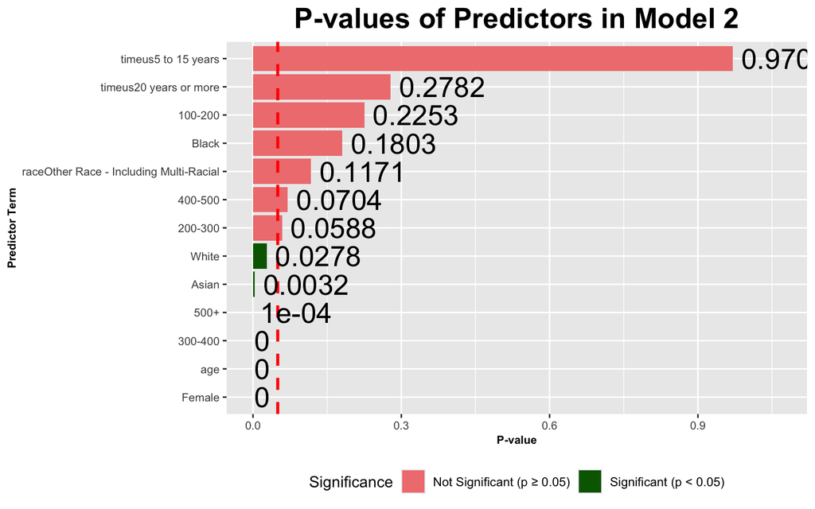

```r
#Extract and Prepare Model 2 Data
model2_data <- tidy(model2) %>%
  # Filter out the (Intercept) for cleaner visualization of predictors
  filter(term != "(Intercept)") %>%
  # Create a significance label
  mutate(
    is_significant = p.value < 0.05,
    short_term = gsub("raceNon-Hispanic |income_pov_cat|gender", "", term)
  )

#Create the P-value Bar Plot
pplot_model2 = ggplot(model2_data, aes(x = p.value, y = reorder(short_term, p.value), fill = is_significant)) +
  geom_bar(stat = "identity") +
  geom_vline(xintercept = 0.05, linetype = "dashed", color = "red", size = 1) +
  geom_text(aes(label = round(p.value, 4)),
            hjust = -0.1,
            color = "black",
            size = 7) +
  xlim(0, max(model2_data$p.value) * 1.1) +
  scale_fill_manual(values = c("TRUE" = "darkgreen", "FALSE" = "lightcoral"),
                    labels = c("Not Significant (p ≥ 0.05)", "Significant (p < 0.05)")) +
  labs(
    title = "P-values of Predictors in Model 2",
    x = "P-value",
    y = "Predictor Term",
    fill = "Significance"
  ) +
  theme(
    #Font sizes
    plot.title = element_text(size = 20, face = "bold", hjust = 0.5),
    axis.title = element_text(size = 8, face = "bold"),
    axis.text  = element_text(size = 8),
    legend.position = "bottom"
  )

#display the plot
pplot_model2
```

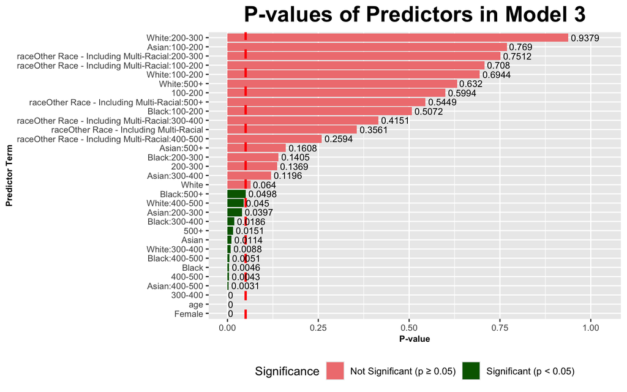

```r
#Extract and Prepare Model 3 Data
pplott_model3 = model3_data <- tidy(model3) %>%
  # Filter out the (Intercept) for cleaner visualization of predictors
  filter(term != "(Intercept)") %>%
  # Create a significance label
  mutate(
    is_significant = p.value < 0.05,
    short_term = gsub("raceNon-Hispanic |income_pov_cat|gender", "", term)
  )

#Create the P-value Bar Plot
pplot_model3 = ggplot(model3_data, aes(x = p.value, y = reorder(short_term, p.value), fill = is_significant)) +
  geom_bar(stat = "identity") +
  geom_vline(xintercept = 0.05, linetype = "dashed", color = "red", size = 1) +
  geom_text(aes(label = round(p.value, 4)),
            hjust = -0.1,
            color = "black",
            size = 3) +
  xlim(0, max(model3_data$p.value) * 1.1) +
  scale_fill_manual(values = c("TRUE" = "darkgreen", "FALSE" = "lightcoral"),
                    labels = c("Not Significant (p ≥ 0.05)", "Significant (p < 0.05)")) +
  labs(
    title = "P-values of Predictors in Model 3",
    x = "P-value",
    y = "Predictor Term",
    fill = "Significance"
  ) +
  theme(
    #Font sizes
    plot.title = element_text(size = 20, face = "bold", hjust = 0.5),
    axis.title = element_text(size = 8, face = "bold"),
    axis.text  = element_text(size = 8),
    legend.position = "bottom"
  )

#display the plot
pplot_model3
```

This plot shows the p-values of the predictors of model3.Most of the interaction terms added in Model 3 have high p-values, meaning they are not statistically significant individually.

**Since Model 3 is much harder to interpret without adding meaningful predictive power, we determined that Model 2 was the better choice for interpretability.**

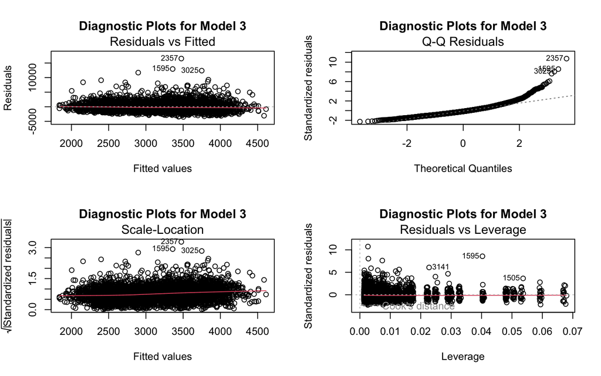

```r
# Comprehensive residual plots
par(mfrow = c(2, 2))
plot(model3, main = "Diagnostic Plots for Model 3")
```

The residual diagnostics indicate that several key linear regression assumptions are violated.

**The Residuals vs. Fitted plot** shows a clear funnel-shaped pattern, with residual variance increasing as fitted sodium intake values rise. This indicates heteroscedasticity, meaning the model’s prediction errors are not constant across levels of the outcome.

**The Q–Q plot** reveals substantial deviations from the reference line, particularly in the upper tail. This suggests that the residuals are not normally distributed and are right-skewed, with more extreme high sodium values than expected under normality.

**The Residuals vs. Leverage plot** identifies a small number of observations with large residuals; however, none exhibit excessively high leverage or Cook’s distance. This indicates that while outliers exist, they are not highly influencing the estimated regression coefficients.

**Despite the clear assumption violations, Model 2 is choosen as the best untransformed option due to its superior interpretability and simplicity. These issues necessitate a data transformation (e.g Log-transformation) to produce a statistically robust model.**

## 4.6 Transformations

```r
food_model$log_sodium = log(food_model$sodium)
```

To address the normality and heteroscedasticity issues we just identified, we applied a logarithmic transformation to our outcome variable.

## 4.7 Histogram of Log-Transformed Sodium Intake

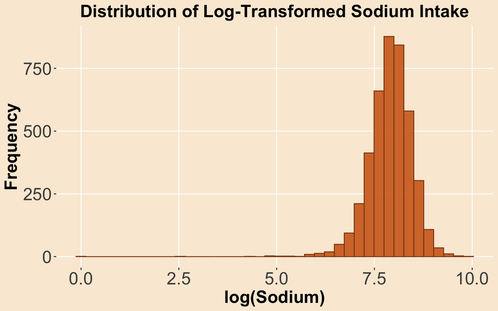

```r
hlog_sodium <- ggplot(food_model, aes(log(sodium))) +
  geom_histogram(
    bins = 40,
    fill = "chocolate",
    color = "chocolate4",
    alpha = 0.9
  ) +
  labs(
    title = "Distribution of Log-Transformed Sodium Intake",
    x = "log(Sodium)",
    y = "Frequency"
  ) +
  theme(
    plot.background = element_rect(fill = "antiquewhite", color = NA),
    panel.background = element_rect(fill = "antiquewhite", color = NA),
    panel.grid.major = element_line(color = "white"),
    panel.grid.minor = element_blank(),
    plot.title = element_text(size = 20, face = "bold", hjust = 0.5),
    axis.title = element_text(size = 20, face = "bold"),
    axis.text  = element_text(size = 20)
  )
# Display
hlog_sodium
```

This histogram shows the distribution of log-transformed sodium intake. After log transformation, the distribution is much more symmetric and bell-shaped, approximating a normal distribution much better.

### 4.7.1 Linear Regression Model With log(sodium)

```r
model_log <- lm(log_sodium ~ age + gender + race + income_pov_cat + timeus + hhsize, data = food_model)
summary(model_log)
```

```
##
## Call:
## lm(formula = log_sodium ~ age + gender + race + income_pov_cat +
##     timeus + hhsize, data = food_model)
##
## Residuals:
##    Min     1Q Median     3Q    Max
## -8.017 -0.283  0.029  0.330  1.902
##
## Coefficients:
##                                          Estimate Std. Error t value Pr(>|t|)
## (Intercept)                              8.040911   0.069824  115.16  < 2e-16
## age                                     -0.004800   0.000515   -9.31  < 2e-16
## genderFemale                            -0.270793   0.016311  -16.60  < 2e-16
## raceNon-Hispanic White                   0.073494   0.024608    2.99  0.00284
## raceNon-Hispanic Black                   0.017588   0.032206    0.55  0.58503
## raceNon-Hispanic Asian                   0.147318   0.045187    3.26  0.00112
## raceOther Race - Including Multi-Racial  0.082674   0.038950    2.12  0.03385
## income_pov_cat100-200                    0.079532   0.028216    2.82  0.00484
## income_pov_cat200-300                    0.100985   0.029733    3.40  0.00069
## income_pov_cat300-400                    0.190937   0.031673    6.03  1.8e-09
## income_pov_cat400-500                    0.126986   0.034409    3.69  0.00023
## income_pov_cat500+                       0.183357   0.027628    6.64  3.6e-11
## timeus5 to 15 years                      0.027137   0.075013    0.36  0.71755
## timeus20 years or more                   0.086542   0.059121    1.46  0.14332
## hhsize                                   0.004805   0.006258    0.77  0.44264
##
## (Intercept)                             ***
## age                                     ***
## genderFemale                            ***
## raceNon-Hispanic White                  **
## raceNon-Hispanic Black
## raceNon-Hispanic Asian                  **
## raceOther Race - Including Multi-Racial *
## income_pov_cat100-200                   **
## income_pov_cat200-300                   ***
## income_pov_cat300-400                   ***
## income_pov_cat400-500                   ***
## income_pov_cat500+                      ***
## timeus5 to 15 years
## timeus20 years or more
## hhsize
## ---
## Signif. codes:  0 '***' 0.001 '**' 0.01 '*' 0.05 '.' 0.1 ' ' 1
##
## Residual standard error: 0.525 on 4225 degrees of freedom
## Multiple R-squared:  0.101,  Adjusted R-squared:  0.0983
## F-statistic:   34 on 14 and 4225 DF,  p-value: <2e-16
```

```r
xkablevif(model_log)
```

VIFs of the model.

| age | genderFemale | hhsize | income_pov_cat100-200 | income_pov_cat200-300 | income_pov_cat300-400 | income_pov_cat400-500 | income_pov_cat500+ | raceNon-Hispanic Asian | raceNon-Hispanic Black | raceNon-Hispanic White | raceOther Race - Including Multi-Racial | timeus20 years or more | timeus5 to 15 years |
| --- | --- | --- | --- | --- | --- | --- | --- | --- | --- | --- | --- | --- | --- |
| 1.14 | 1.01 | 1.14 | 1.93 | 1.84 | 1.73 | 1.6 | 2.32 | 1.27 | 1.57 | 2.17 | 1.35 | 2.44 | 2.3 |

**This model uses log(sodium intake) as the dependent variable to address skewness and heteroscedasticity observed in the untransformed models.The predictors include age, gender, race, income category, length of time in the U.S., and household size.**

**Coefficient Interpretation**

**Mutiple R-squared = 0.101 (10.1%)**. This model explains approximately 10.1% of the total variation in daily sodium intake.

**Adjusted R-squared = 0.0983** The adjusted value confirms that the demographic and socioeconomic factors explain slightly under 10% of the variance.

**F-statistic p-value < 2.2e-16**.The overall model is statistically significant, meaning that the predictors, as a group,predict log(sodium) intake.

### 4.7.2 Comprehensive residual plots

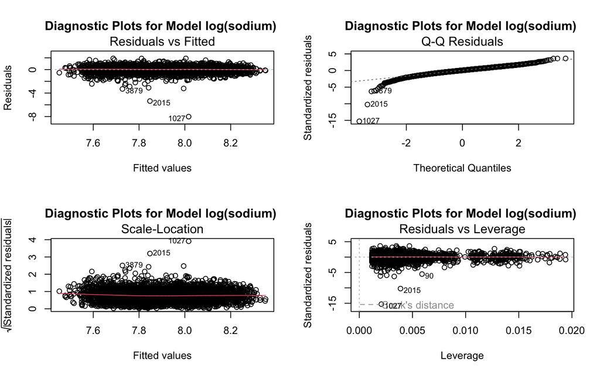

```r
par(mfrow = c(2, 2))
plot(model_log, main = "Diagnostic Plots for Model log(sodium) ")
```

These plots for the final model with log(sodium intake) as the dependent variable indicate that the linear regression assumptions are substantially better satisfied compared to the untransformed models.

**Residuals vs Fitted**:The residuals are now randomly scattered around zero with a relatively constant spread across all fitted values.This indicates that the log transformation has effectively corrected the heteroscedasticity problem. Prediction errors are now more stable across low, medium, and high levels of sodium intake.

**Residuals vs Leverage**: A small number of observations show relatively large standardized residuals; however, none approach the Cook’s distance threshold. This indicates that while some outliers remain, they do not exert disproportionate influence on the estimated regression coefficients.

## 4.8 Conclusions Sodium Intake Model

In conclusion, while demographic variables explain only about a small amount of the variation in sodium consumption, we identified distinct, statistically significant patterns:

- **Women consume significantly less sodium than men.**
- **Older adults tend to consume less sodium than younger adults.**
- **Higher Income groups and Non-Hispanic White or Asian populations are associated with significantly higher sodium intake.**

These findings are crucial for public health, as they help identify exactly which groups are at higher risk for excessive sodium consumption.

# 5 Model to predict the probability of a healthy diet

## 5.1 Constructing the Healthy Diet Score (Gender-Specific)

We construct a healthy diet score ranging from 0–7, where each point corresponds to meeting one NIH dietary benchmark. Because recommended intake differs by gender, we apply gender-specific thresholds for calories, protein, fiber, and carbohydrates. A binary outcome variable (healthy_diet) is then created, where 1 indicates meeting at least 5 of the 7 criteria. Roughly 24% of respondents meet this threshold, indicating a class imbalance.

```r
food = read_parquet("proc_data/demo_foods.parquet")
# Create a gender-specific healthy diet score based on NIH benchmarks
food <- food %>%
  mutate(
    healthy_score = case_when(
      # Female thresholds (RIAGENDR == 2)
      RIAGENDR == 2 ~ (
        (DR1IKCAL_sum <= 2000) +
        (DR1ISODI_sum < 2300) +
        (DR1IPROT_sum >= 50) +
        (DR1ISUGR_sum <= 50) +
        (DR1ICARB_sum <= 275) +
        (DR1IFIBE_sum >= 28) +
        (DR1ITFAT_sum <= 78)
      ),
      # Male thresholds (RIAGENDR == 1)
      RIAGENDR == 1 ~ (
        (DR1IKCAL_sum <= 2500) +
        (DR1ISODI_sum < 2300) +
        (DR1IPROT_sum >= 56) +
        (DR1ISUGR_sum <= 50) +
        (DR1ICARB_sum <= 300) +
        (DR1IFIBE_sum >= 31) +
        (DR1ITFAT_sum <= 88)
      )
    ),
    # Healthy if meeting at least 5 out of 7 criteria
    healthy_diet = if_else(healthy_score >= 5, 1, 0)
  )

# Distribution of healthy vs unhealthy
table(food$healthy_diet)
```

```
##
##    0    1
## 3612 1148
```

```r
prop.table(table(food$healthy_diet))
```

```
##
##     0     1
## 0.759 0.241
```

To simplify interpretation and avoid sparse categories, we regroup marital status and race variables into broader, more balanced groups. Hispanic respondents are combined into a single category, and marital status is collapsed into partnered, widowed/separated, and single.

```r
# Recode marital status
food <- food %>%
  mutate(
    marital_recode = case_when(
      DMDMARTZ %in% c(1, 6) ~ "Partnered",
      DMDMARTZ %in% c(2, 4) ~ "Wid/Separated",
      TRUE ~ "Single"
    )
  )

# Recode race/ethnicity
food <- food %>%
  mutate(
    race_recode = case_when(
      RIDRETH3 %in% c(1, 2) ~ "Hispanic",
      RIDRETH3 == 3 ~ "White",
      RIDRETH3 == 4 ~ "Black",
      TRUE ~ "Other"
    )
  )
```

Here we prepare the final modeling dataset by converting categorical variables to factors and removing observations with missing values. The final dataset includes demographic predictors commonly used in diet research.

```r
# Convert categorical variables to factors
food$healthy_diet   <- factor(food$healthy_diet)
food$RIAGENDR       <- factor(food$RIAGENDR)
food$race_recode    <- factor(food$race_recode)
food$marital_recode <- factor(food$marital_recode)
food$DMDEDUC2       <- factor(food$DMDEDUC2)

# Select variables for modeling
model_data <- food %>%
  dplyr::select(
    healthy_diet,
    RIAGENDR,
    RIDAGEYR,
    race_recode,
    marital_recode,
    DMDEDUC2,
    INDFMPIR
  ) %>%
  tidyr::drop_na()
```

## 5.2 Stepwise Logistic Regression and ANOVA Comparison

We estimate a series of nested logistic regression models and compare them using likelihood ratio tests. Education significantly improves model fit, income does not add explanatory power once gender-adjusted thresholds are used, race improves the model modestly, and marital status does not significantly improve fit.

```r
# Model A: age + gender
model_A <- glm(healthy_diet ~ RIAGENDR + RIDAGEYR,
               data = model_data, family = binomial)

# Model B: add education
model_B <- glm(healthy_diet ~ RIAGENDR + RIDAGEYR + DMDEDUC2,
               data = model_data, family = binomial)

anova(model_A, model_B, test = "Chisq")
```

```
## Analysis of Deviance Table
##
## Model 1: healthy_diet ~ RIAGENDR + RIDAGEYR
## Model 2: healthy_diet ~ RIAGENDR + RIDAGEYR + DMDEDUC2
##   Resid. Df Resid. Dev Df Deviance Pr(>Chi)
## 1      4206       4560
## 2      4202       4537  4     22.7  0.00015 ***
## ---
## Signif. codes:  0 '***' 0.001 '**' 0.01 '*' 0.05 '.' 0.1 ' ' 1
```

```r
# Model C: add income
model_C <- glm(healthy_diet ~ RIAGENDR + RIDAGEYR + DMDEDUC2 + INDFMPIR,
               data = model_data, family = binomial)

anova(model_B, model_C, test = "Chisq")
```

```
## Analysis of Deviance Table
##
## Model 1: healthy_diet ~ RIAGENDR + RIDAGEYR + DMDEDUC2
## Model 2: healthy_diet ~ RIAGENDR + RIDAGEYR + DMDEDUC2 + INDFMPIR
##   Resid. Df Resid. Dev Df Deviance Pr(>Chi)
## 1      4202       4537
## 2      4201       4535  1     2.63     0.11
```

```r
# Model D: add race
model_D <- glm(healthy_diet ~ RIAGENDR + RIDAGEYR + DMDEDUC2 +
                 INDFMPIR + race_recode,
               data = model_data, family = binomial)

anova(model_C, model_D, test = "Chisq")
```

```
## Analysis of Deviance Table
##
## Model 1: healthy_diet ~ RIAGENDR + RIDAGEYR + DMDEDUC2 + INDFMPIR
## Model 2: healthy_diet ~ RIAGENDR + RIDAGEYR + DMDEDUC2 + INDFMPIR + race_recode
##   Resid. Df Resid. Dev Df Deviance Pr(>Chi)
## 1      4201       4535
## 2      4198       4526  3     8.99    0.029 *
## ---
## Signif. codes:  0 '***' 0.001 '**' 0.01 '*' 0.05 '.' 0.1 ' ' 1
```

```r
# Model E: add marital status
model_E <- glm(healthy_diet ~ RIAGENDR + RIDAGEYR + DMDEDUC2 +
                 INDFMPIR + race_recode + marital_recode,
               data = model_data, family = binomial)

anova(model_D, model_E, test = "Chisq")
```

```
## Analysis of Deviance Table
##
## Model 1: healthy_diet ~ RIAGENDR + RIDAGEYR + DMDEDUC2 + INDFMPIR + race_recode
## Model 2: healthy_diet ~ RIAGENDR + RIDAGEYR + DMDEDUC2 + INDFMPIR + race_recode +
##     marital_recode
##   Resid. Df Resid. Dev Df Deviance Pr(>Chi)
## 1      4198       4526
## 2      4196       4524  2     1.35     0.51
```

## 5.3 Final Model Selection

Using a 0.5 cutoff, the model achieves relatively high accuracy (~76%) but extremely low sensitivity. This reflects the strong class imbalance and indicates that demographic variables alone are poor predictors of healthy diet status. However, accuracyis not a good metric here; sensitivity/roc/auc matter more.

```r
model3 <- model_D
# Predicted probabilities
pred_prob3 <- predict(model3, type = "response")

# Classification using 0.5 cutoff
pred_class3 <- if_else(pred_prob3 >= 0.5, 1, 0)

# Confusion matrix
conf_mat3 <- table(pred_class3, model_data$healthy_diet)
conf_mat3
```

```
##
## pred_class3    0    1
##           0 3203 1004
##           1    1    1
```

```r
# Performance metrics
cutoff <- 0.5
TN <- conf_mat3["0","0"]
FP <- conf_mat3["1","0"]
FN <- conf_mat3["0","1"]
TP <- conf_mat3["1","1"]

metrics <- list(
  Cutoff_used = cutoff,
  Accuracy = (TP + TN) / (TP + TN + FP + FN),
  Sensitivity = TP / (TP + FN),
  Specificity = TN / (TN + FP),
  Precision = TP / (TP + FP)
)

metrics
```

```
## $Cutoff_used
## [1] 0.5
##
## $Accuracy
## [1] 0.761
##
## $Sensitivity
## [1] 0.000995
##
## $Specificity
## [1] 1
##
## $Precision
## [1] 0.5
```

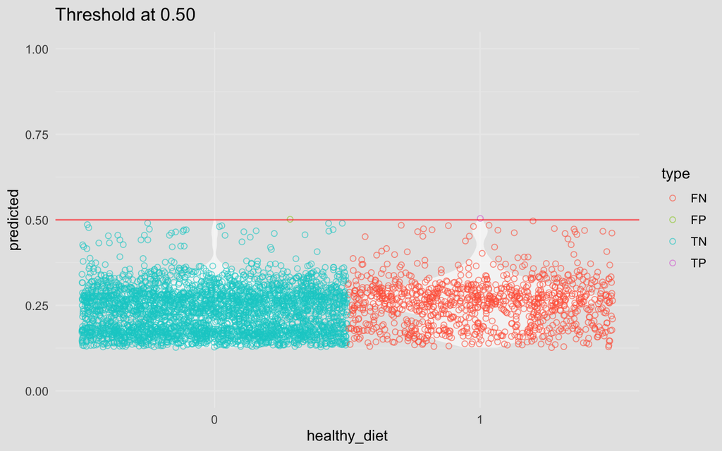

```r
df_plot=tibble( healthy_diet = model3$y, pred= model3$fitted.values) |>
  mutate(type = case_when(
      healthy_diet == 1 & pred >= cutoff ~ "TP",
      healthy_diet == 0 & pred >= cutoff ~ "FP",
      healthy_diet == 1 & pred <  cutoff ~ "FN",
      healthy_diet == 0 & pred <  cutoff ~ "TN"
    ), type = factor(type, levels = c("FN", "FP", "TN", "TP")))

cols <- c(FN = "tomato", FP = "yellowgreen", TN = "cyan3", TP = "orchid")

ggplot(df_plot, aes(x = factor(healthy_diet), y = pred)) +
  geom_violin(fill = "white", color = NA, alpha = 0.6, trim = TRUE) +
  geom_jitter(aes(color = type), width  = 0.5, height = 0, alpha  = 0.6, size   = 1.8, fill   = NA, shape  = 21,) +
  geom_hline(yintercept = cutoff, color = "red", alpha = 0.6) +
  scale_color_manual(values = cols, name = "type") +
  scale_y_continuous(limits = c(0, 1)) +
  labs(title = sprintf("Threshold at %.2f", cutoff), x = "healthy_diet", y = "predicted") +
  theme_minimal(base_size = 12) +
  theme( panel.background = element_rect(fill = "gray90", color = NA),
    plot.background  = element_rect(fill = "gray90", color = NA))
```

##. Visualizations

The visualizations highlight the distribution of diet scores by gender and confirm that the model performs only slightly better than random guessing (AUC ≈ 0.60), reinforcing the conclusion that demographics alone cannot strongly predict diet quality.

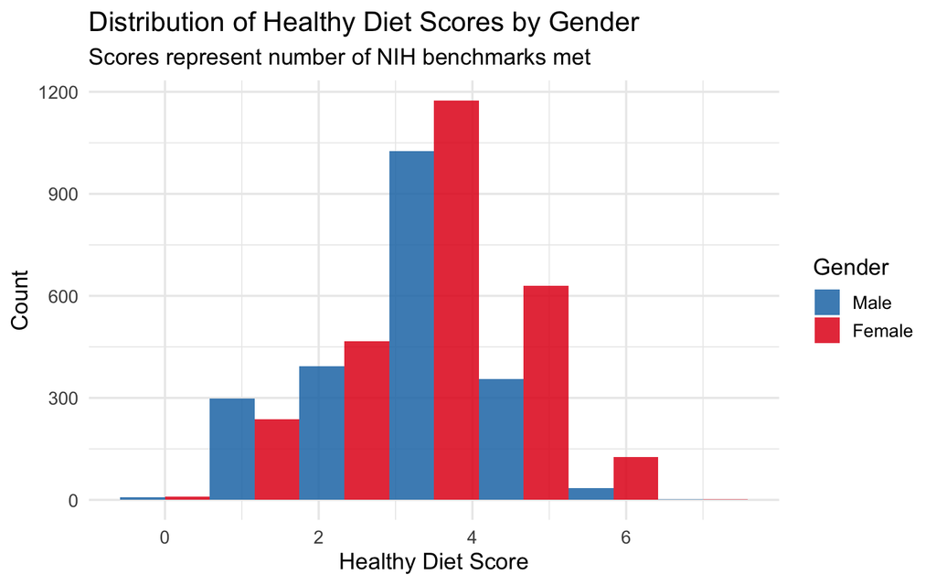

```r
# Distribution of healthy diet scores by gender
ggplot(food, aes(x = healthy_score, fill = RIAGENDR)) +
  geom_histogram(position = "dodge", bins = 7, alpha = 0.85) +
  scale_fill_manual(values = c("#1f78b4", "#e31a1c"),
                    labels = c("Male", "Female")) +
  labs(
    title = "Distribution of Healthy Diet Scores by Gender",
    subtitle = "Scores represent number of NIH benchmarks met",
    x = "Healthy Diet Score",
    y = "Count",
    fill = "Gender"
  ) +
  theme_minimal(base_size = 14)
```

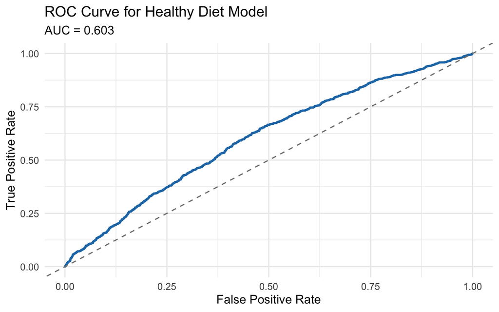

```r
library(pROC)
roc_obj <- roc(model_data$healthy_diet, pred_prob3)

ggplot(data.frame(
  tpr = roc_obj$sensitivities,
  fpr = 1 - roc_obj$specificities),
  aes(x = fpr, y = tpr)) +
  geom_line(color = "#1f78b4", linewidth = 1.2) +
  geom_abline(linetype = "dashed", color = "grey50") +
  labs(
    title = "ROC Curve for Healthy Diet Model",
    subtitle = paste("AUC =", round(auc(roc_obj), 3)),
    x = "False Positive Rate",
    y = "True Positive Rate"
  ) +
  theme_minimal(base_size = 14)
```

Overall, the goal was to predict whether someone meets a gender-adjusted healthy diet definition (at least 5 out of 7 NIH-style benchmarks) using demographics. Stepwise ANOVA suggests education improves model fit and race adds a small improvement, while income and marital status do not add much once the scoring is gender-adjusted. Model performance is limited (AUC ≈ 0.60), and with a 0.5 cutoff it predicts almost everyone as “unhealthy,” so accuracy is driven mostly by class imbalance rather than strong prediction. In other words, the model is better for describing broad trends than for accurately predicting healthy diet status for individuals, and it suggests most people do not meet the NIH benchmarks.

## 5.4 Conclusions Healthy Diet Model

Using gender-adjusted NIH benchmarks avoids bias and reveals meaningful differences in diet quality. Education consistently predicts healthier diets, while income no longer matters once gender-specific nutritional needs are accounted for. Although the model captures broad demographic trends, it performs poorly at individual-level prediction, reflecting both class imbalance and the limits of demographics alone. Overall, the results clearly show that most Americans do not meet NIH nutritional benchmarks.

# 6 Conclusions

Taken together, the three empirical models on sugar intake, sodium intake, and healthy diet quality provide a consistent and nuanced picture of dietary behavior in the United States. Across all outcomes, demographic characteristics explain only a modest share of variation in nutritional intake, underscoring the complexity of dietary behavior and the limits of relying on socioeconomic or demographic factors alone to predict or change diet quality.

Several patterns emerge consistently across models. Gender is a robust and persistent predictor: women consume significantly less sugar and sodium than men and are more likely to meet healthy diet benchmarks once gender-specific nutritional needs are appropriately accounted for. Age also matters for certain nutrients, with older adults consuming less sodium, suggesting that dietary risks vary meaningfully over the life course. In contrast, income plays a surprisingly limited role. Sugar intake shows no clear income gradient, and income loses explanatory power for healthy diet quality once benchmarks are adjusted for gender. These findings suggest that economic resources alone are insufficient to explain differences in dietary intake and that interventions narrowly targeted by income may have limited effectiveness.

Racial and ethnic disparities appear in both sugar and sodium consumption, though not always in the same direction. Non-Hispanic White individuals exhibit higher intake of both sugar and sodium relative to Hispanic individuals, while Non-Hispanic Black individuals consume more sugar and Asian individuals consume more sodium. These heterogeneous patterns point to the influence of cultural dietary norms, food environments, and consumption habits that are not fully captured by standard demographic controls.

Behavioral factors, particularly eating patterns, emerge as especially important for sugar intake. The strong association between snacking frequency and sugar consumption highlights how daily food choices and meal structure may drive excess intake more than traditional socioeconomic indicators. At the same time, the positive association between home-prepared meals and sugar intake suggests that higher eating frequency, rather than diet quality per se, may increase total exposure to sugar. These results reinforce the need to distinguish between quantity, timing, and composition of meals when evaluating dietary risks.

Despite identifying statistically significant correlates, all three models perform poorly in explaining individual-level variation. The sugar and sodium models exhibit low explanatory power, and the healthy diet model struggles with prediction due to class imbalance and the inherent limitations of demographic predictors. Diagnostic evidence of heteroskedasticity and non-normal residuals in the sugar model further emphasizes that substantial unobserved factors—such as preferences, habits, food marketing exposure, geographic access, and local food environments—likely play a central role in shaping dietary outcomes.

From a public health perspective, the findings converge on an important conclusion: most Americans fail to meet established nutritional benchmarks, and excess intake of sugar and sodium remains widespread across demographic groups. While fiscal and regulatory policies such as sugar-sweetened beverage taxes may contribute to reductions in consumption, the results suggest that broader, more comprehensive strategies are needed. Policies that improve access to healthy foods, address geographic disparities in food environments, enhance nutrition education, and strengthen food labeling may be more effective in shifting population-level dietary patterns than approaches focused solely on income or demographic targeting.

Overall, this study highlights the value of combining nutrient-specific models with broader measures of diet quality. Doing so reveals both shared and distinct determinants of unhealthy consumption and underscores the importance of moving beyond demographics toward behavioral, environmental, and structural explanations. Future research incorporating richer behavioral data and spatial indicators of food access will be essential for designing more effective and equitable nutrition policies.

# References

Backholer, K., Sarink, D., Beauchamp, A., Keating, C., Loh, V., Ball, K., Martin, J., et al. (2016). The impact of a tax on sugar-sweetened beverages according to socio-economic position: A systematic review of the evidence. *Public Health Nutrition*, *19*(17), 3070–3084. Retrieved December 12, 2025, from https://www.cambridge.org/core/journals/public-health-nutrition/article/impact-of-a-tax-on-sugarsweetened-beverages-according-to-socioeconomic-position-a-systematic-review-of-the-evidence/587CFDC392441741771A93E7F652E222

Brown-University. (2025). COVID-19 Habits We Should Keep After the Pandemic Brown University Health. Retrieved October 21, 2025, from https://www.brownhealth.org/be-well/covid-19-habits-we-should-keep-after-pandemic

CDC. (2024, October). Get the Facts: Added Sugars. *Nutrition*. Retrieved December 12, 2025, from https://www.cdc.gov/nutrition/php/data-research/added-sugars.html

Dumoitier, A., Abbo, V., Neuhofer, Z. T., & McFadden, B. R. (2019). A review of nutrition labeling and food choice in the United States. *Obesity Science & Practice*, *5*(6), 581–591. Retrieved December 12, 2025, from https://onlinelibrary.wiley.com/doi/10.1002/osp4.374

Lewis, M., Herron, L.-M., Chatfield, M. D., Tan, R. C., Dale, A., Nash, S., & Lee, A. J. (2023). Healthy Food Prices Increased More Than the Prices of Unhealthy Options during the COVID-19 Pandemic and Concurrent Challenges to the Food System. *International Journal of Environmental Research and Public Health*, *20*(4), 3146. Retrieved October 21, 2025, from https://www.ncbi.nlm.nih.gov/pmc/articles/PMC9967271/

Pandey, V., Mohan, R., Kumar, A., Gangadevi, P., & Kurien, N. (2023). [The Impact of the COVID-19 Outbreak on Lifestyle-Related Behavior Among the General Population](https://doi.org/10.7759/cureus.45756). *Cureus*, *15*(9), e45756.

Sharma, A., Hauck, K., Hollingsworth, B., & Siciliani, L. (2014). THE EFFECTS OF TAXING SUGAR‐SWEETENED BEVERAGES ACROSS DIFFERENT INCOME GROUPS. *Health Economics*, *23*(9), 1159–1184. Retrieved December 12, 2025, from https://onlinelibrary.wiley.com/doi/10.1002/hec.3070

Silva, P., Araújo, R., Lopes, F., & Ray, S. (2023). Nutrition and Food Literacy: Framing the Challenges to Health Communication. *Nutrients*, *15*(22), 4708. Retrieved December 12, 2025, from https://www.ncbi.nlm.nih.gov/pmc/articles/PMC10674981/

Toomer, O. (2016). Nutrition education and promotion in the U.S. *Journal of Food*, *1*(1). Retrieved December 12, 2025, from https://www.ars.usda.gov/research/publications/publication/?seqNo115=336389

U.S. Department of Agriculture, Agricultural Research Service. (2024). What We Eat in America, National Health and Nutrition Examination Survey (NHANES) August 2021-August 2023. Retrieved from https://www.ars.usda.gov/northeast-area/beltsville-md-bhnrc/beltsville-human-nutrition-research-center/food-surveys-research-group/docs/wweia-documentation-and-data-sets/

Walker, R. E., Keane, C. R., & Burke, J. G. (2010). Disparities and access to healthy food in the United States: A review of food deserts literature. *Health & Place*, *16*(5), 876–884. Retrieved December 12, 2025, from https://linkinghub.elsevier.com/retrieve/pii/S1353829210000584

Williams, A., Terry, A., Akinbami, L., Ansai, N., & Ogden, C. (2025). *What We Eat in America dietary data, NHANES: August 2021–August 2023 24-hour dietary recall interview mode change*. U.S. Department of Health; Human Services. Retrieved from https://wwwn.cdc.gov/nchs/data/Nhanes/Public/2021/Whitepapers/Aug2023-What-We-Eat-In-America-Dietary-Data-Whitepaper.pdf